# Monitoring Estimates

This is the code to generate the estimates tables using the monitoring (water-point level) approach.

# NOTES

- general approach for NAs in promoter_surveyed and pm_ea_list in wp_census and hh_survey: I have changed NA to FALSE; but this should probably be done in wrangling
- I have used pm_survey to count the number of households in the promoter survey in table 11
- I have used ea_list_uganda and ea_list_malawi for the number of WPs int the EA list in table 9
- I have used pm_survey_households for table 11 and to tackle double-counted hhs in table 14
- for table 1 ex households located outside of village, I did a rough number. ideally, i just rerun the table 1 code here but without households that have inclusion as within 200m of village boundary for a more exact number
- TO DO: have both fcr and tcr in main tables

# load packages

```r
packages <-
  c(
    "stringr",
    "sf",
    "tidyverse",
    "viridis",
    "glue",
    "patchwork",
    "tidyr",
    "dplyr",
    "knitr",
    "kableExtra",
    "vtable",
    "stargazer",
    "ggplot2",
    "haven",
    "estimatr",
    "janitor"
  )

pacman::p_load(
  packages,
  character.only = TRUE
)
```

# setup

## define path_box

```r
path_box <- "/Users/lenawisniewska/Library/CloudStorage/Box-Box/i-h2o-takeup"
```

## load datasets

```r
villages <-
  read_rds(
    file.path(
      path_box,
      "Data",
      "Villages",
      "DataSets",
      "Final",
      "villages.rds"
    )
  )

pm_survey <-
  read_rds(
    file.path(
      path_box,
      "Data",
      "PromoterSurvey",
      "DataSets",
      "Final",
      "pm-survey.rds"
    )
  ) %>%
  left_join(wp_census %>%
              select(wp_id, intervention_type, sample_group, country, intervention),
            by = "wp_id")

ea_list_uganda <-
  read_csv(
    file.path(
      path_box,
      "Data",
      "PromoterSurvey",
      "DataSets",
      "Raw",
      "promoter_list_uganda.csv"
    )
  ) %>%
  left_join(wp_census %>%
            mutate(ea_id = as.numeric(ea_id)) %>%
            select(ea_id, intervention_type, country, intervention),
          by = c("i102_wpt_id" = "ea_id"))
ea_list_malawi <-
  read_csv(
    file.path(
      path_box,
      "Data",
      "PromoterSurvey",
      "DataSets",
      "Raw",
      "promoter_list_malawi.csv"
    )
  ) %>%
  left_join(wp_census %>%
            mutate(ea_id = as.numeric(ea_id)) %>%
            select(ea_id, intervention_type, country, intervention),
          by = c("i102_wpt_id" = "ea_id"))
hh_survey <-
  read_rds(
    file.path(
      path_box,
      "Data",
      "HouseholdSurvey",
      "DataSets",
      "Final",
      "hh-survey.rds"
    )
  ) %>%
  left_join(wp_census %>%
              select(wp_id, intervention_type, intervention),
            by = "wp_id") %>%
  left_join(hh_census %>%
              select(household_id, inclusion),
            by = "household_id")

hh_census <-
  read_rds(
    file.path(
      path_box,
      "Data",
      "HouseholdCensus",
      "DataSets",
      "Final",
      "hh-census.rds"
    )
  ) %>%
  left_join(wp_census %>%
              select(wp_id, intervention_type, intervention),
            by = "wp_id")

pm_survey_households <-
  read_rds(
    file.path(
      path_box,
      "Data",
      "PromoterSurvey",
      "DataSets",
      "Constructed",
      "pm-survey-households.rds"
    )
  )

wp_census <-
  read_rds(
    file.path(
      path_box,
      "Data",
      "WaterPointCensus",
      "DataSets",
      "Final",
      "wp-census.rds"
    )
  ) %>%
  mutate(ea_id = as.character(ea_id))

# Uganda
uganda_wp <- read_dta(file.path(path_box, "Data", "EvidenceAction", "Final", "uganda-water-points.dta")) %>%
  mutate(villageid = as.character(villageid))

uganda_villages <- read_dta(file.path(path_box, "Data", "EvidenceAction", "Final", "uganda-villages.dta")) %>%
  mutate(villageid = as.character(villageid))

uganda_wcp <- read_dta(file.path(path_box, "Data", "EvidenceAction", "Final", "uganda-water-collection-points.dta"))

# Malawi
malawi_wp <- read_dta(file.path(path_box, "Data", "EvidenceAction", "Final", "malawi-water-points.dta")) %>%
  mutate(villageid = as.character(villageid))

malawi_villages <- read_dta(file.path(path_box, "Data", "EvidenceAction", "Final", "malawi-villages.dta")) %>%
  mutate(villageid = as.character(villageid))

malawi_wcp <- read_dta(file.path(path_box, "Data", "EvidenceAction", "Final", "malawi-water-collection-points.dta"))
```

## rank dataset (from randomization)

```r
pm_survey_clean <-
  read_rds(
    file.path(
      path_box,
      "Data",
      "PromoterSurvey",
      "DataSets",
      "Clean",
      "pm-survey-clean.rds"
    )
  )

randomization <- pm_survey_clean %>%
  dplyr::select(
    wp_id, village_id, country,
    contains("rand_hh")
  ) %>%
  pivot_longer(
    cols = starts_with("rand_hh"),
    names_prefix = "rand_hh_",
    names_to = "rank",
    values_to = "household_name",
    values_drop_na = TRUE
  ) %>%
  mutate(household_name = household_name %>% str_squish %>% str_trim)


hhc <-
  read_rds(
    file.path(
      path_box,
      "Data",
      "HouseholdCensus",
      "DataSets",
      "Constructed",
      "hh-census-constructed.rds"
    )
  ) %>%
  select(village_id, household_id, household_name)

randomization_id <-
  randomization %>%
  left_join(hhc)
hh_survey <- hh_survey %>%
  left_join(
    randomization_id %>% select(household_id, rank),
    by = "household_id"
  )
# if this code is not commented out, we include households that would have been selected for the monitoring survey but had already been present in the household survey
# hh_survey <- hh_survey %>%
#   mutate(
#     rank = as.numeric(rank),
#     survey = as.character(survey),  # Convert to character first
#     survey = ifelse(survey == "Household Survey" & !is.na(rank) & rank <= 4,
#                     "Monitoring Survey",
#                     survey)
#   )
```

## country totals

I get the same numbers as before if I classify by water point, not by village for expansion and footprint

```r
# malawi
malawi_villages <- malawi_villages %>%
  mutate(
    sample_group = case_when(
      ilc == 1 ~ "ILC",
      ilc == 0 & dsw == 1 & pre_expansion == 1 ~ "Footprint",
      ilc == 0 & dsw == 1 & pre_expansion == 0 ~ "Expansion"
    )
  )

malawi_wp <- malawi_wp %>%
  left_join(malawi_villages %>% select(villageid, sample_group, pre_expansion_village = pre_expansion, ilc, dsw), by = "villageid") %>%
  mutate(
    intervention = case_when(
      program == 1 ~ "DSW",
      program == 2 ~ "ILC",
      TRUE ~ "Non-program"
    ),
    wp_sample_group = case_when(
      ilc == 1 ~ "ILC",
      ilc == 0 & dsw == 1 & pre_expansion == 1 ~ "Footprint",
      ilc == 0 & dsw == 1 & pre_expansion == 0 ~ "Expansion"
    ),
    country = "Malawi"
  )

malawi_ilc_wcp_count <- nrow(malawi_wcp)

# uganda
uganda_villages <- uganda_villages %>%
  mutate(
    sample_group = case_when(
      ilc == 1 ~ "ILC",
      ilc == 0 & dsw == 1 & pre_expansion == 1 ~ "Footprint",
      ilc == 0 & dsw == 1 & pre_expansion == 0 ~ "Expansion"
    )
  )

uganda_wp <- uganda_wp %>%
  left_join(uganda_villages %>% select(villageid, sample_group, pre_expansion_village = pre_expansion, ilc, dsw), by = "villageid") %>%
  mutate(
    intervention = case_when(
      program == 1 ~ "DSW",
      program == 2 ~ "ILC water point",
      TRUE ~ "Non-program"
    ),
     wp_sample_group = case_when(
      ilc == 1 ~ "ILC",
      ilc == 0 & dsw == 1 & pre_expansion == 1 ~ "Footprint",
      ilc == 0 & dsw == 1 & pre_expansion == 0 ~ "Expansion"
     ),
    country = "Uganda")

uganda_ilc_wcp_count <- nrow(uganda_wcp)

# create country totals table
country_totals <- bind_rows(malawi_wp, uganda_wp) %>%
  count(country, wp_sample_group, intervention, name = "country_total") %>%
  # Add ILC water collection points to the ILC category
  mutate(
    country_total = case_when(
      country == "Malawi" & intervention == "ILC" ~ country_total + malawi_ilc_wcp_count,
      country == "Uganda" & intervention == "ILC" ~ country_total + uganda_ilc_wcp_count,
      TRUE ~ country_total
    )
  ) %>%
  arrange(country, wp_sample_group, intervention) %>%
  mutate(sample_group = wp_sample_group) %>%
  select(-wp_sample_group)
country_totals
```

| country | intervention | country_total | sample_group |
| --- | --- | --- | --- |
| Malawi | DSW | 12040 | Expansion |
| Malawi | ILC | 2028 | Expansion |
| Malawi | DSW | 3123 | Footprint |
| Malawi | DSW | 1035 | ILC |
| Malawi | ILC | 2364 | ILC |
| Malawi | ILC | 2032 | NA |
| Uganda | DSW | 12528 | Expansion |
| Uganda | DSW | 4606 | Footprint |
| Uganda | DSW | 584 | ILC |
| Uganda | ILC water point | 282 | ILC |

## create function for SEs

```r
compute_se <- function(values, ses = NULL, include_within = FALSE) {
  values <- unlist(values)
  ses <- unlist(ses)

  K <- length(values)
  if (K <= 1) {
    between_var <- 0
  } else {
    mean_val <- mean(values, na.rm = TRUE)
    between_var <- sum((values - mean_val)^2, na.rm = TRUE) / (K * (K - 1))
  }

  within_var <- 0
  if (include_within && K > 0 && length(ses) == K) {
    within_var <- sum(ses^2, na.rm = TRUE) / (K^2)
  }

  total_var <- between_var + within_var
  se <- sqrt(total_var)

  tibble(mean_val = mean(values, na.rm = TRUE), se = se)
}
```

## create function for by water point type table

```r
create_summary_table <- function(count_tbl, stats_tbl, totals_tbl,
                                 group_vars = c("country", "sample_group", "intervention")) {

  count_tbl %>%
    left_join(stats_tbl, by = group_vars) %>%
    left_join(totals_tbl, by = group_vars) %>%
    mutate(
      indiv_access_sample = avg_hh_count * avg_hh_size,
      indiv_access_popn   = indiv_access_sample * country_total,
      se_indiv_access_sample = sqrt((avg_hh_size^2) * (se_hh_count^2) + (avg_hh_count^2) * (se_hh_size^2)),
      se_indiv_access_popn   = country_total * se_indiv_access_sample,
      ci_lower_indiv_access_popn = indiv_access_popn - 1.96 * se_indiv_access_popn,
      ci_upper_indiv_access_popn = indiv_access_popn + 1.96 * se_indiv_access_popn,
      ci_lower_chl_rate = avg_chl_rate - 1.96 * se_chl_rate,
      ci_upper_chl_rate = avg_chl_rate + 1.96 * se_chl_rate
    ) %>%
    mutate(across(c(avg_hh_count, avg_hh_size, indiv_access_sample, indiv_access_popn,
                    se_hh_count, se_hh_size, se_indiv_access_sample, se_indiv_access_popn,
                    ci_lower_indiv_access_popn, ci_upper_indiv_access_popn),
                  ~ round(.x, 2))) %>%
    arrange(across(all_of(group_vars)))
}
```

## create function for country estimates table

```r
compute_country_totals <- function(data,
                                   group_var = "country",
                                   value_col = "indiv_access_popn",
                                   se_col = "se_indiv_access_popn",
                                   ci_level = 0.95) {

  # Calculate z-score for confidence level
  z_score <- qnorm(1 - (1 - ci_level) / 2)

  # Create dynamic column names for output
  total_col <- paste0("total_", value_col)
  se_total_col <- paste0("se_total_", value_col)
  ci_lower_col <- paste0("ci_lower_total_", gsub("^indiv_access_popn$", "access", value_col))
  ci_upper_col <- paste0("ci_upper_total_", gsub("^indiv_access_popn$", "access", value_col))

  data %>%
    # Replace NAs with 0 in value and SE columns before calculation
    mutate(
      across(all_of(c(value_col, se_col)), ~replace_na(.x, 0))
    ) %>%
    group_by(across(all_of(group_var))) %>%
    summarise(
      !!total_col := sum(.data[[value_col]], na.rm = TRUE),
      !!se_total_col := sqrt(sum(.data[[se_col]]^2, na.rm = TRUE)),
      .groups = "drop"
    ) %>%
    mutate(
      !!ci_lower_col := .data[[total_col]] - z_score * .data[[se_total_col]],
      !!ci_upper_col := .data[[total_col]] + z_score * .data[[se_total_col]]
    ) %>%
    select(all_of(group_var),
           all_of(total_col),
           all_of(ci_lower_col),
           all_of(ci_upper_col))
}
```

# sample tables

## water points (9)

```r
wp_table <- wp_census %>%
  group_by(country, sample_group, intervention) %>%
  summarise(
    wp_census = n_distinct(wp_id),
    wp_functional = n_distinct(wp_id[wp_func == TRUE]),
    promoter_surveyed = n_distinct(wp_id[promoter_surveyed == TRUE]),
    # ea_list = n_distinct(wp_id[pm_ea_list == TRUE]),
    .groups = "drop"
  ) %>%
  left_join(country_totals, by = c("country", "sample_group", "intervention")) %>%
  left_join(
    ea_list_malawi %>%
      group_by(country, sample_group, intervention) %>%
      summarise(ea_list_malawi_count = n_distinct(i102_wpt_id), .groups = "drop"),
    by = c("country", "sample_group", "intervention")
  ) %>%
  left_join(
    ea_list_uganda %>%
      group_by(country, sample_group, intervention) %>%
      summarise(ea_list_uganda_count = n_distinct(i102_wpt_id), .groups = "drop"),
    by = c("country", "sample_group", "intervention")
  )

wp_table
```

| country | sample_group | intervention | wp_census | wp_functional | promoter_surveyed | country_total | ea_list_malawi_count | ea_list_uganda_count |
| --- | --- | --- | --- | --- | --- | --- | --- | --- |
| Malawi | Footprint | DSW | 51 | 48 | 46 | 3123 | 48 | NA |
| Malawi | Footprint | Non-program | 106 | 88 | 2 | NA | 6 | NA |
| Malawi | Expansion | DSW | 86 | 85 | 60 | 12040 | 75 | NA |
| Malawi | Expansion | ILC | 4 | 4 | 0 | 2028 | NA | NA |
| Malawi | Expansion | Non-program | 59 | 55 | 0 | NA | 2 | NA |
| Malawi | ILC | DSW | 65 | 64 | 43 | 1035 | 52 | NA |
| Malawi | ILC | ILC | 175 | 151 | 45 | 2364 | 1 | NA |
| Malawi | ILC | Non-program | 107 | 80 | 4 | NA | 3 | NA |
| Uganda | Footprint | DSW | 60 | 60 | 38 | 4606 | NA | 36 |
| Uganda | Footprint | ILC | 10 | 8 | 3 | NA | NA | 2 |
| Uganda | Footprint | Non-program | 171 | 146 | 1 | NA | NA | 2 |
| Uganda | Expansion | DSW | 125 | 117 | 77 | 12528 | NA | 81 |
| Uganda | Expansion | ILC | 1 | 0 | 0 | NA | NA | NA |
| Uganda | Expansion | Non-program | 157 | 116 | 1 | NA | NA | NA |

text for table caption: For Uganda, 2 of the 112 water points in the EA promoter list were identified as ILC, and are not shown. For Malawi, 2 out of 137 were identified as Non-program and are not shown.

```r
wp_census %>%
  dplyr::filter(country == "Malawi") %>%
  dplyr::filter(pm_ea_list == TRUE) %>%
  count(intervention)
```

| intervention | n |
| --- | --- |
| DSW | 134 |
| ILC | 1 |
| Non-program | 2 |

```r
wp_census %>%
  dplyr::filter(country == "Uganda") %>%
  dplyr::filter(pm_ea_list == TRUE) %>%
  count(intervention)
```

| intervention | n |
| --- | --- |
| DSW | 109 |
| ILC | 2 |
| Non-program | 1 |

## households (11)

```r
# renaming intervention in hh census for consistency
hh_census <- hh_census %>%
  mutate(intervention = wp_intervention) %>%
  select(-wp_intervention)

# number of water points in the promoter survey
wp_count_pm <- wp_census %>%
  dplyr::filter(promoter_surveyed == TRUE) %>%
  group_by(country, sample_group, intervention) %>%
  summarise(
    wp_count_pm = n_distinct(wp_id),
    .groups = "drop"
  )

# number of households in the promoter survey
pm_users <- wp_census %>%
  mutate(pm_users = as.numeric(pm_users)) %>%
  group_by(country, sample_group, intervention) %>%
  summarise(
    pm_users = sum(pm_users, na.rm = TRUE),
    .groups = "drop"
  )

# number of households from the promoter survey that are also in the HH census - represented by the variable cal_hh_count for each WP
pm_users_census <- wp_census %>%
  mutate(pm_users_census = as.numeric(pm_users_census)) %>%
  group_by(country, sample_group, intervention) %>%
  summarise(
    pm_users_census = sum(pm_users_census, na.rm = TRUE),
    .groups = "drop"
  )

# number of households whose self-report in HH census matches the promoter's report
pm_hh_matched <- pm_survey_households %>%
  left_join(wp_census %>% select(wp_id, sample_group, intervention),
            by = c("wp_id_c" = "wp_id")) %>%
  dplyr::filter(!is.na(sample_group)) %>%
  dplyr::filter(!is.na(intervention)) %>%
  dplyr::filter(household_id %in% hh_census$household_id) %>%
  left_join(hh_census %>% select(household_id, wp_id),
            by = "household_id", suffix = c("_pm", "_census")) %>%
  mutate(wp_match = wp_id_c == wp_id_census) %>%
  group_by(country, sample_group, intervention) %>%
  summarise(
    pm_hh_matched = sum(wp_match, na.rm = TRUE),
    .groups = "drop") %>%
  mutate(country = toupper(country))

# number of households outside of the village
pm_users_outside <- wp_census %>%
  mutate(pm_users_outside = as.numeric(pm_users_outside)) %>%
  group_by(country, sample_group, intervention) %>%
  summarise(
    pm_users_outside = sum(pm_users_outside, na.rm = TRUE),
    .groups = "drop"
  )

# total number of water points in the wp census
wp_count_wp_census <- wp_census %>%
  group_by(country, sample_group, intervention) %>%
  summarise(
    wp_count_wp_census = n_distinct(wp_id),
    .groups = "drop"
  )

# total number of households that report using the water points in the wp census, regardless of whether they are in the promoter survey or not
census_hh_listed <- hh_census %>%
  dplyr::filter(wp_id %in% wp_census$wp_id) %>%
  group_by(country, sample_group, intervention) %>%
  summarise(
    census_hh_listed = n_distinct(household_id),
    .groups = "drop"
  )

# average numbers of households per water point
pm_avg_hh_per_wp <- wp_census %>%
  mutate(pm_users = as.numeric(pm_users)) %>%
  group_by(country, sample_group, intervention) %>%
  summarise(
    pm_avg_hh_per_wp = round(mean(pm_users, na.rm = TRUE), 2),
    .groups = "drop"
  )

census_avg_hh_per_wp <- hh_census %>%
  dplyr::filter(wp_id %in% wp_census$wp_id) %>%
  group_by(country, sample_group, intervention, wp_id) %>%
  summarise(
    census_hh_listed = n_distinct(household_id),   # households per wp
    .groups = "drop"
  ) %>%
  group_by(country, sample_group, intervention) %>%
  summarise(
    census_avg_hh_per_wp = round(mean(census_hh_listed, na.rm = TRUE), 2),  # avg across wps
    .groups = "drop"
  )

# table
hh_tbl <- wp_count_pm  %>%
  left_join(pm_users, by = c("country", "sample_group", "intervention")) %>%
  left_join(pm_users_outside, by = c("country", "sample_group", "intervention")) %>%
  left_join(pm_users_census, by = c("country", "sample_group", "intervention")) %>%
  left_join(pm_hh_matched, by = c("country", "sample_group", "intervention")) %>%
  left_join(pm_avg_hh_per_wp, by = c("country", "sample_group", "intervention")) %>%
  left_join(wp_count_wp_census, by = c("country", "sample_group", "intervention")) %>%
  left_join(census_hh_listed, by = c("country", "sample_group", "intervention")) %>%
  left_join(census_avg_hh_per_wp, by = c("country", "sample_group", "intervention"))
  # dplyr::filter(wp_category %in% c("DSW Footprint", "DSW Expansion", "DSW in ILC village", "ILC")) %>%
  # dplyr::filter(!(country == "UGANDA" & wp_category == "ILC")) %>%
  # mutate(country = factor(country, levels = c("MALAWI", "UGANDA"))) %>%
  # mutate(wp_category = factor(wp_category, levels = c("DSW Footprint", "DSW Expansion", "DSW in ILC village", "ILC"))) %>%
  # arrange(country, wp_category)

hh_tbl
```

| country | sample_group | intervention | wp_count_pm | pm_users | pm_users_outside | pm_users_census | pm_hh_matched | pm_avg_hh_per_wp | wp_count_wp_census | census_hh_listed | census_avg_hh_per_wp |
| --- | --- | --- | --- | --- | --- | --- | --- | --- | --- | --- | --- |
| Malawi | Footprint | DSW | 46 | 2140 | 255 | 1497 | NA | 46.52 | 51 | 1334 | 27.22 |
| Malawi | Footprint | Non-program | 2 | 56 | 0 | 60 | NA | 28.00 | 106 | 1263 | 15.22 |
| Malawi | Expansion | DSW | 60 | 2247 | 175 | 1653 | NA | 37.45 | 86 | 2234 | 26.92 |
| Malawi | ILC | DSW | 43 | 1770 | 123 | 1188 | NA | 41.16 | 65 | 1669 | 27.36 |
| Malawi | ILC | ILC | 45 | 983 | 51 | 785 | NA | 21.84 | 175 | 1264 | 9.23 |
| Malawi | ILC | Non-program | 4 | 118 | 13 | 114 | NA | 29.50 | 107 | 1235 | 17.90 |
| Uganda | Footprint | DSW | 38 | 1909 | 274 | 1349 | NA | 50.24 | 60 | 1973 | 34.61 |
| Uganda | Footprint | ILC | 3 | 115 | 44 | 82 | NA | 38.33 | 10 | 96 | 13.71 |
| Uganda | Footprint | Non-program | 1 | 0 | 0 | 1 | NA | 0.00 | 171 | 930 | 9.89 |
| Uganda | Expansion | DSW | 77 | 2591 | 84 | 2049 | NA | 34.09 | 125 | 4087 | 34.34 |
| Uganda | Expansion | Non-program | 1 | 64 | 0 | 51 | NA | 64.00 | 157 | 1067 | 11.73 |

# estimates tables

## main monitoring estimates (8)

```r
hh_count <- wp_census %>%
  group_by(country, sample_group, intervention) %>%
  # use pm list of users
  summarise(wp_values = list(pm_users[!is.na(pm_users)]), .groups = "drop") %>%
  rowwise() %>%
  mutate(tmp = list(compute_se(wp_values, include_within = FALSE))) %>%
  unnest_wider(tmp, names_sep = "_") %>%
  rename(
    avg_hh_count = tmp_mean_val,
    se_hh_count = tmp_se
  ) %>%
  select(country, sample_group, intervention, avg_hh_count, se_hh_count)

hh_stats <- hh_survey %>%
  # use monitoring survey
  dplyr::filter(survey == "Monitoring Survey") %>%
  group_by(country, sample_group, intervention, wp_id) %>%
  summarize(
    # hh size and chlorination rates
    hh_size = mean(hh_members, na.rm = TRUE),
    chl_rate = mean(disctcr_02, na.rm = TRUE),
    se_chl_rate = sqrt(chl_rate * (1 - chl_rate) / n()),  # within-WP SE
    .groups = "drop_last"
  ) %>%
  group_by(country, sample_group, intervention) %>%
  summarize(
    wp_hh_sizes = list(hh_size[!is.na(hh_size)]),
    wp_rates = list(chl_rate[!is.na(chl_rate)]),
    wp_ses = list(se_chl_rate[!is.na(se_chl_rate)]),
    .groups = "drop"
  ) %>%
  rowwise() %>%
  mutate(
    hh_tmp = list(compute_se(wp_hh_sizes, include_within = FALSE)),
    chl_tmp = list(compute_se(wp_rates, wp_ses, include_within = TRUE))
  ) %>%
  unnest_wider(hh_tmp, names_sep = "_") %>%
  unnest_wider(chl_tmp, names_sep = "_") %>%
  rename(
    avg_hh_size = hh_tmp_mean_val,
    se_hh_size = hh_tmp_se,
    avg_chl_rate = chl_tmp_mean_val,
    se_chl_rate = chl_tmp_se
  ) %>%
  select(country, sample_group, intervention, avg_hh_size, se_hh_size, avg_chl_rate, se_chl_rate)

# water point type table
table8 <- create_summary_table(hh_count, hh_stats, country_totals)
table8
```

| country | sample_group | intervention | avg_hh_count | se_hh_count | avg_hh_size | se_hh_size | avg_chl_rate | se_chl_rate | country_total | indiv_access_sample | indiv_access_popn | se_indiv_access_sample | se_indiv_access_popn | ci_lower_indiv_access_popn | ci_upper_indiv_access_popn | ci_lower_chl_rate | ci_upper_chl_rate |
| --- | --- | --- | --- | --- | --- | --- | --- | --- | --- | --- | --- | --- | --- | --- | --- | --- | --- |
| Malawi | Expansion | DSW | 37.45 | 2.41 | 4.83 | 0.13 | 0.3019632 | 0.0496670 | 12040 | 181.06 | 2179905.4 | 12.61 | 151782.22 | 1882412.2 | 2477398.5 | 0.2046159 | 0.3993105 |
| Malawi | Expansion | ILC | NaN | 0.00 | 2.50 | 0.00 | 0.0000000 | 0.0000000 | 2028 | NaN | NaN | NaN | NaN | NaN | NaN | 0.0000000 | 0.0000000 |
| Malawi | Expansion | Non-program | NaN | 0.00 | 3.62 | 1.03 | 0.0000000 | 0.0000000 | NA | NaN | NA | NaN | NA | NA | NA | 0.0000000 | 0.0000000 |
| Malawi | Footprint | DSW | 46.52 | 4.14 | 4.58 | 0.24 | 0.3414286 | 0.0621416 | 3123 | 212.96 | 665070.3 | 21.88 | 68343.30 | 531117.5 | 799023.2 | 0.2196310 | 0.4632261 |
| Malawi | Footprint | Non-program | 28.00 | 7.00 | 4.56 | 0.31 | 0.0909091 | 0.0569263 | NA | 127.70 | NA | 33.10 | NA | NA | NA | -0.0206665 | 0.2024846 |
| Malawi | ILC | DSW | 41.16 | 4.39 | 4.34 | 0.17 | 0.2768620 | 0.0581791 | 1035 | 178.64 | 184896.0 | 20.37 | 21082.99 | 143573.4 | 226218.7 | 0.1628309 | 0.3908931 |
| Malawi | ILC | ILC | 21.84 | 1.56 | 4.25 | 0.19 | 0.2286164 | 0.0524672 | 2364 | 92.78 | 219327.7 | 7.79 | 18421.19 | 183222.2 | 255433.2 | 0.1257806 | 0.3314521 |
| Malawi | ILC | Non-program | 29.50 | 7.79 | 4.59 | 0.23 | 0.0309524 | 0.0232981 | NA | 135.49 | NA | 36.44 | NA | NA | NA | -0.0147119 | 0.0766166 |
| Uganda | Expansion | DSW | 34.09 | 2.76 | 6.17 | 0.23 | 0.4283069 | 0.0447966 | 12528 | 210.25 | 2634020.2 | 18.79 | 235371.94 | 2172691.2 | 3095349.2 | 0.3405056 | 0.5161081 |
| Uganda | Expansion | ILC | NaN | 0.00 | NA | NA | NA | NA | NA | NA | NA | NA | NA | NA | NA | NA | NA |
| Uganda | Expansion | Non-program | 64.00 | 0.00 | 6.97 | 0.67 | 0.2543860 | 0.0979423 | NA | 446.12 | NA | 43.12 | NA | NA | NA | 0.0624190 | 0.4463529 |
| Uganda | Footprint | DSW | 50.24 | 4.04 | 5.83 | 0.38 | 0.4485714 | 0.0743553 | 4606 | 293.10 | 1350029.0 | 30.22 | 139178.30 | 1077239.6 | 1622818.5 | 0.3028351 | 0.5943077 |
| Uganda | Footprint | ILC | 38.33 | 12.33 | 6.50 | 0.29 | 0.3333333 | 0.3333333 | NA | 249.17 | NA | 80.93 | NA | NA | NA | -0.3200000 | 0.9866667 |
| Uganda | Footprint | Non-program | 0.00 | 0.00 | 5.43 | 0.69 | 0.2916667 | 0.1117589 | NA | 0.00 | NA | 0.00 | NA | NA | NA | 0.0726192 | 0.5107141 |

```r
# country estimates table
country_estimates_table8 <- compute_country_totals(table8)
country_estimates_table8
```

| country | total_indiv_access_popn | ci_lower_total_access | ci_upper_total_access |
| --- | --- | --- | --- |
| Malawi | 3249199 | 2918363 | 3580036 |
| Uganda | 3984049 | 3448113 | 4519986 |

## using HH census and HH survey; only using WPs in promoter survey (10)

```r
hh_count <- hh_census %>%
  # use water points in promoter survey
  dplyr::filter(promoter_surveyed == 1) %>%
  group_by(country, sample_group, intervention, wp_id) %>%
  summarise(
    hh_count = n_distinct(household_id),   # number of distinct households per wp
    .groups = "drop"
  ) %>%
  group_by(country, sample_group, intervention) %>%
  summarise(
    wp_values = list(hh_count[!is.na(hh_count)]),
    .groups = "drop"
  ) %>%
  rowwise() %>%
  mutate(tmp = list(compute_se(wp_values, include_within = FALSE))) %>%
  unnest_wider(tmp, names_sep = "_") %>%
  rename(
    avg_hh_count = tmp_mean_val,
    se_hh_count = tmp_se
  ) %>%
  select(country, sample_group, intervention, avg_hh_count, se_hh_count)

hh_stats <- hh_survey %>%
  # use household survey
  dplyr::filter(survey == "Household Survey") %>%
  # use water points in promoter survey
  dplyr::filter(promoter_surveyed == 1) %>%
  group_by(country, sample_group, intervention, wp_id) %>%
  summarize(
    hh_size = mean(hh_members, na.rm = TRUE),
    chl_rate = mean(disctcr_02, na.rm = TRUE),
    se_chl_rate = sqrt(chl_rate * (1 - chl_rate) / n()),  # within-WP SE
    .groups = "drop_last"
  ) %>%
  group_by(country, sample_group, intervention) %>%
  summarize(
    wp_hh_sizes = list(hh_size[!is.na(hh_size)]),
    wp_rates = list(chl_rate[!is.na(chl_rate)]),
    wp_ses = list(se_chl_rate[!is.na(se_chl_rate)]),
    .groups = "drop"
  ) %>%
  rowwise() %>%
  mutate(
    hh_tmp = list(compute_se(wp_hh_sizes, include_within = FALSE)),
    chl_tmp = list(compute_se(wp_rates, wp_ses, include_within = TRUE))
  ) %>%
  unnest_wider(hh_tmp, names_sep = "_") %>%
  unnest_wider(chl_tmp, names_sep = "_") %>%
  rename(
    avg_hh_size = hh_tmp_mean_val,
    se_hh_size = hh_tmp_se,
    avg_chl_rate = chl_tmp_mean_val,
    se_chl_rate = chl_tmp_se
  ) %>%
  select(country, sample_group, intervention, avg_hh_size, se_hh_size, avg_chl_rate, se_chl_rate)

# water point type table
table10 <- create_summary_table(hh_count, hh_stats, country_totals)
table10
```

| country | sample_group | intervention | avg_hh_count | se_hh_count | avg_hh_size | se_hh_size | avg_chl_rate | se_chl_rate | country_total | indiv_access_sample | indiv_access_popn | se_indiv_access_sample | se_indiv_access_popn | ci_lower_indiv_access_popn | ci_upper_indiv_access_popn | ci_lower_chl_rate | ci_upper_chl_rate |
| --- | --- | --- | --- | --- | --- | --- | --- | --- | --- | --- | --- | --- | --- | --- | --- | --- | --- |
| Malawi | Expansion | DSW | 28.58 | 2.18 | 4.67 | 0.15 | 0.2460347 | 0.0420952 | 12040 | 133.45 | 1606714.4 | 10.98 | 132210.35 | 1347582.1 | 1865846.7 | 0.1635280 | 0.3285413 |
| Malawi | Footprint | DSW | 29.30 | 3.24 | 4.49 | 0.12 | 0.2900621 | 0.0452047 | 3123 | 131.63 | 411081.1 | 14.97 | 46764.16 | 319423.3 | 502738.8 | 0.2014609 | 0.3786633 |
| Malawi | Footprint | Non-program | 19.00 | 11.00 | 4.02 | 1.02 | 0.0238095 | 0.0332685 | NA | 76.45 | NA | 48.35 | NA | NA | NA | -0.0413967 | 0.0890157 |
| Malawi | ILC | DSW | 31.17 | 3.66 | 4.35 | 0.13 | 0.2338894 | 0.0513614 | 1035 | 135.73 | 140478.1 | 16.48 | 17059.25 | 107041.9 | 173914.2 | 0.1332211 | 0.3345577 |
| Malawi | ILC | ILC | 16.42 | 1.66 | 4.58 | 0.18 | 0.3069231 | 0.0582063 | 2364 | 75.30 | 178009.6 | 8.18 | 19343.97 | 140095.4 | 215923.8 | 0.1928389 | 0.4210074 |
| Malawi | ILC | Non-program | 20.00 | 9.00 | 5.37 | 0.93 | 0.0370370 | 0.0449140 | NA | 107.32 | NA | 51.78 | NA | NA | NA | -0.0509944 | 0.1250685 |
| Uganda | Expansion | DSW | 38.80 | 3.16 | 5.55 | 0.20 | 0.3794324 | 0.0463694 | 12528 | 215.45 | 2699124.8 | 19.17 | 240172.46 | 2228386.7 | 3169862.8 | 0.2885485 | 0.4703164 |
| Uganda | Expansion | Non-program | 12.00 | 0.00 | NA | NA | NA | NA | NA | NA | NA | NA | NA | NA | NA | NA | NA |
| Uganda | Footprint | DSW | 38.76 | 4.89 | 5.59 | 0.15 | 0.3457895 | 0.0482666 | 4606 | 216.77 | 998430.7 | 27.96 | 128797.93 | 745986.8 | 1250874.7 | 0.2511870 | 0.4403920 |
| Uganda | Footprint | ILC | 23.00 | 11.59 | 6.40 | 1.40 | 0.3181818 | 0.3263417 | NA | 147.20 | NA | 80.86 | NA | NA | NA | -0.3214478 | 0.9578115 |

```r
# country estimates table
country_estimates_table10 <- compute_country_totals(table10)
country_estimates_table10
```

| country | total_indiv_access_popn | ci_lower_total_access | ci_upper_total_access |
| --- | --- | --- | --- |
| Malawi | 2336283 | 2056814 | 2615753 |
| Uganda | 3697555 | 3163410 | 4231701 |

## using HH census and HH survey; all water points (12)

```r
hh_count <- hh_census %>%
  group_by(country, sample_group, intervention, wp_id) %>%
  summarise(
    hh_count = n_distinct(household_id),   # number of distinct households per wp
    .groups = "drop"
  ) %>%
  group_by(country, sample_group, intervention) %>%
  summarise(
    wp_values = list(hh_count[!is.na(hh_count)]),
    .groups = "drop"
  ) %>%
  rowwise() %>%
  mutate(tmp = list(compute_se(wp_values, include_within = FALSE))) %>%
  unnest_wider(tmp, names_sep = "_") %>%
  rename(
    avg_hh_count = tmp_mean_val,
    se_hh_count = tmp_se
  ) %>%
  select(country, sample_group, intervention, avg_hh_count, se_hh_count)

hh_stats <- hh_survey %>%
  # use household survey
  dplyr::filter(survey == "Household Survey") %>%
  group_by(country, sample_group, intervention, wp_id) %>%
  summarize(
    hh_size = mean(hh_members, na.rm = TRUE),
    chl_rate = mean(disctcr_02, na.rm = TRUE),
    se_chl_rate = sqrt(chl_rate * (1 - chl_rate) / n()),  # within-WP SE
    .groups = "drop_last"
  ) %>%
  group_by(country, sample_group, intervention) %>%
  summarize(
    wp_hh_sizes = list(hh_size[!is.na(hh_size)]),
    wp_rates = list(chl_rate[!is.na(chl_rate)]),
    wp_ses = list(se_chl_rate[!is.na(se_chl_rate)]),
    .groups = "drop"
  ) %>%
  rowwise() %>%
  mutate(
    hh_tmp = list(compute_se(wp_hh_sizes, include_within = FALSE)),
    chl_tmp = list(compute_se(wp_rates, wp_ses, include_within = TRUE))
  ) %>%
  unnest_wider(hh_tmp, names_sep = "_") %>%
  unnest_wider(chl_tmp, names_sep = "_") %>%
  rename(
    avg_hh_size = hh_tmp_mean_val,
    se_hh_size = hh_tmp_se,
    avg_chl_rate = chl_tmp_mean_val,
    se_chl_rate = chl_tmp_se
  ) %>%
  select(country, sample_group, intervention, avg_hh_size, se_hh_size, avg_chl_rate, se_chl_rate)

# water point type table
table12 <- create_summary_table(hh_count, hh_stats, country_totals)
table12
```

| country | sample_group | intervention | avg_hh_count | se_hh_count | avg_hh_size | se_hh_size | avg_chl_rate | se_chl_rate | country_total | indiv_access_sample | indiv_access_popn | se_indiv_access_sample | se_indiv_access_popn | ci_lower_indiv_access_popn | ci_upper_indiv_access_popn | ci_lower_chl_rate | ci_upper_chl_rate |
| --- | --- | --- | --- | --- | --- | --- | --- | --- | --- | --- | --- | --- | --- | --- | --- | --- | --- |
| Malawi | Expansion | DSW | 26.92 | 1.77 | 4.69 | 0.13 | 0.2247187 | 0.0359978 | 12040 | 126.36 | 1521434.2 | 9.00 | 108360.32 | 1309048.01 | 1733820.5 | 0.1541630 | 0.2952745 |
| Malawi | Expansion | ILC | 11.25 | 1.11 | 4.83 | 0.44 | 0.6666667 | 0.3333333 | 2028 | 54.38 | 110272.5 | 7.30 | 14809.13 | 81246.60 | 139298.4 | 0.0133333 | 1.3200000 |
| Malawi | Expansion | Non-program | 14.92 | 1.80 | 5.70 | 0.86 | 0.0333333 | 0.0451335 | NA | 85.05 | NA | 16.43 | NA | NA | NA | -0.0551284 | 0.1217951 |
| Malawi | Expansion | NA | 205.00 | 0.00 | 5.22 | 0.60 | 0.1875000 | 0.1387524 | NA | 1070.56 | NA | 123.32 | NA | NA | NA | -0.0844547 | 0.4594547 |
| Malawi | Footprint | DSW | 27.22 | 3.05 | 4.50 | 0.11 | 0.2929469 | 0.0442408 | 3123 | 122.64 | 383004.0 | 14.11 | 44058.30 | 296649.76 | 469358.3 | 0.2062349 | 0.3796588 |
| Malawi | Footprint | Non-program | 15.22 | 1.51 | 4.12 | 0.36 | 0.0523810 | 0.0460317 | NA | 62.77 | NA | 8.29 | NA | NA | NA | -0.0378413 | 0.1426032 |
| Malawi | Footprint | NA | 830.00 | 0.00 | 4.17 | 0.34 | 0.1956522 | 0.0760373 | NA | 3458.33 | NA | 281.42 | NA | NA | NA | 0.0466191 | 0.3446852 |
| Malawi | ILC | DSW | 27.36 | 2.81 | 4.38 | 0.12 | 0.2356293 | 0.0468435 | 1035 | 119.83 | 124025.7 | 12.77 | 13213.74 | 98126.73 | 149924.6 | 0.1438160 | 0.3274426 |
| Malawi | ILC | ILC | 9.23 | 0.80 | 4.77 | 0.13 | 0.2492561 | 0.0370080 | 2364 | 43.99 | 103991.6 | 4.01 | 9473.92 | 85422.70 | 122560.5 | 0.1767205 | 0.3217917 |
| Malawi | ILC | Non-program | 17.90 | 2.86 | 4.75 | 0.27 | 0.0418651 | 0.0258072 | NA | 84.94 | NA | 14.39 | NA | NA | NA | -0.0087170 | 0.0924472 |
| Malawi | ILC | NA | 676.00 | 0.00 | 4.31 | 0.21 | 0.1696429 | 0.0490191 | NA | 2915.97 | NA | 140.11 | NA | NA | NA | 0.0735655 | 0.2657202 |
| Uganda | Expansion | DSW | 34.34 | 2.46 | 5.42 | 0.18 | 0.3148355 | 0.0368718 | 12528 | 186.13 | 2331812.3 | 14.71 | 184309.76 | 1970565.13 | 2693059.4 | 0.2425667 | 0.3871043 |
| Uganda | Expansion | Non-program | 11.73 | 1.83 | 6.62 | 0.91 | 0.4000000 | 0.2449490 | NA | 77.58 | NA | 16.13 | NA | NA | NA | -0.0801000 | 0.8801000 |
| Uganda | Expansion | NA | 951.00 | 0.00 | 3.50 | 0.50 | 0.5000000 | 0.3118048 | NA | 3328.50 | NA | 475.50 | NA | NA | NA | -0.1111374 | 1.1111374 |
| Uganda | Footprint | DSW | 34.61 | 3.66 | 5.72 | 0.17 | 0.2711502 | 0.0412169 | 4606 | 197.93 | 911662.3 | 21.78 | 100339.04 | 714997.76 | 1108326.8 | 0.1903649 | 0.3519354 |
| Uganda | Footprint | ILC | 13.71 | 5.78 | 5.64 | 1.09 | 0.4072727 | 0.1988508 | NA | 77.35 | NA | 35.87 | NA | NA | NA | 0.0175252 | 0.7970203 |
| Uganda | Footprint | Non-program | 9.89 | 1.57 | 4.90 | 1.03 | 0.1000000 | 0.1000000 | NA | 48.48 | NA | 12.76 | NA | NA | NA | -0.0960000 | 0.2960000 |
| Uganda | Footprint | NA | 421.00 | 0.00 | 5.08 | 1.00 | 0.4666667 | 0.2325383 | NA | 2140.08 | NA | 422.46 | NA | NA | NA | 0.0108915 | 0.9224418 |

```r
# country estimates table
country_estimates_table12 <- compute_country_totals(table12)
country_estimates_table12
```

| country | total_indiv_access_popn | ci_lower_total_access | ci_upper_total_access |
| --- | --- | --- | --- |
| Malawi | 2242728 | 2009445 | 2476011 |
| Uganda | 3243475 | 2832171 | 3654778 |

## excluding HHs outside village (13)

exactly like table 8, but subtract pm_users_outside from pm_users

```r
hh_count <- wp_census %>%
  mutate(pm_users_adjusted = pm_users - pm_users_outside) %>%
  group_by(country, sample_group, intervention) %>%
  summarise(wp_values = list(pm_users_adjusted[!is.na(pm_users_adjusted)]), .groups = "drop") %>%
  rowwise() %>%
  mutate(tmp = list(compute_se(wp_values, include_within = FALSE))) %>%
  unnest_wider(tmp, names_sep = "_") %>%
  rename(
    avg_hh_count = tmp_mean_val,
    se_hh_count = tmp_se
  ) %>%
  select(country, sample_group, intervention, avg_hh_count, se_hh_count)

hh_stats <- hh_survey %>%
  # use monitoring survey
  dplyr::filter(survey == "Monitoring Survey") %>%
  group_by(country, sample_group, intervention, wp_id) %>%
  summarize(
    # hh size and chlorination rates
    hh_size = mean(hh_members, na.rm = TRUE),
    chl_rate = mean(disctcr_02, na.rm = TRUE),
    se_chl_rate = sqrt(chl_rate * (1 - chl_rate) / n()),  # within-WP SE
    .groups = "drop_last"
  ) %>%
  group_by(country, sample_group, intervention) %>%
  summarize(
    wp_hh_sizes = list(hh_size[!is.na(hh_size)]),
    wp_rates = list(chl_rate[!is.na(chl_rate)]),
    wp_ses = list(se_chl_rate[!is.na(se_chl_rate)]),
    .groups = "drop"
  ) %>%
  rowwise() %>%
  mutate(
    hh_tmp = list(compute_se(wp_hh_sizes, include_within = FALSE)),
    chl_tmp = list(compute_se(wp_rates, wp_ses, include_within = TRUE))
  ) %>%
  unnest_wider(hh_tmp, names_sep = "_") %>%
  unnest_wider(chl_tmp, names_sep = "_") %>%
  rename(
    avg_hh_size = hh_tmp_mean_val,
    se_hh_size = hh_tmp_se,
    avg_chl_rate = chl_tmp_mean_val,
    se_chl_rate = chl_tmp_se
  ) %>%
  select(country, sample_group, intervention, avg_hh_size, se_hh_size, avg_chl_rate, se_chl_rate)

# water point type table
table13 <- create_summary_table(hh_count, hh_stats, country_totals)
table13
```

| country | sample_group | intervention | avg_hh_count | se_hh_count | avg_hh_size | se_hh_size | avg_chl_rate | se_chl_rate | country_total | indiv_access_sample | indiv_access_popn | se_indiv_access_sample | se_indiv_access_popn | ci_lower_indiv_access_popn | ci_upper_indiv_access_popn | ci_lower_chl_rate | ci_upper_chl_rate |
| --- | --- | --- | --- | --- | --- | --- | --- | --- | --- | --- | --- | --- | --- | --- | --- | --- | --- |
| Malawi | Expansion | DSW | 34.53 | 2.61 | 4.83 | 0.13 | 0.3019632 | 0.0496670 | 12040 | 166.95 | 2010130.8 | 13.36 | 160898.23 | 1694770.3 | 2325491.3 | 0.2046159 | 0.3993105 |
| Malawi | Expansion | ILC | NaN | 0.00 | 2.50 | 0.00 | 0.0000000 | 0.0000000 | 2028 | NaN | NaN | NaN | NaN | NaN | NaN | 0.0000000 | 0.0000000 |
| Malawi | Expansion | Non-program | NaN | 0.00 | 3.62 | 1.03 | 0.0000000 | 0.0000000 | NA | NaN | NA | NaN | NA | NA | NA | 0.0000000 | 0.0000000 |
| Malawi | Footprint | DSW | 40.98 | 4.15 | 4.58 | 0.24 | 0.3414286 | 0.0621416 | 3123 | 187.58 | 585821.3 | 21.30 | 66532.15 | 455418.3 | 716224.3 | 0.2196310 | 0.4632261 |
| Malawi | Footprint | Non-program | 28.00 | 7.00 | 4.56 | 0.31 | 0.0909091 | 0.0569263 | NA | 127.70 | NA | 33.10 | NA | NA | NA | -0.0206665 | 0.2024846 |
| Malawi | ILC | DSW | 38.30 | 4.55 | 4.34 | 0.17 | 0.2768620 | 0.0581791 | 1035 | 166.23 | 172047.3 | 20.85 | 21582.45 | 129745.7 | 214348.9 | 0.1628309 | 0.3908931 |
| Malawi | ILC | ILC | 20.71 | 1.53 | 4.25 | 0.19 | 0.2286164 | 0.0524672 | 2364 | 87.96 | 207948.5 | 7.58 | 17917.45 | 172830.3 | 243066.7 | 0.1257806 | 0.3314521 |
| Malawi | ILC | Non-program | 26.25 | 8.32 | 4.59 | 0.23 | 0.0309524 | 0.0232981 | NA | 120.56 | NA | 38.69 | NA | NA | NA | -0.0147119 | 0.0766166 |
| Uganda | Expansion | DSW | 33.11 | 2.79 | 6.17 | 0.23 | 0.4283069 | 0.0447966 | 12528 | 204.17 | 2557883.4 | 18.84 | 236081.23 | 2095164.1 | 3020602.6 | 0.3405056 | 0.5161081 |
| Uganda | Expansion | ILC | NaN | 0.00 | NA | NA | NA | NA | NA | NA | NA | NA | NA | NA | NA | NA | NA |
| Uganda | Expansion | Non-program | 64.00 | 0.00 | 6.97 | 0.67 | 0.2543860 | 0.0979423 | NA | 446.12 | NA | 43.12 | NA | NA | NA | 0.0624190 | 0.4463529 |
| Uganda | Footprint | DSW | 43.03 | 4.39 | 5.83 | 0.38 | 0.4485714 | 0.0743553 | 4606 | 251.03 | 1156258.5 | 30.30 | 139584.20 | 882673.5 | 1429843.5 | 0.3028351 | 0.5943077 |
| Uganda | Footprint | ILC | 23.67 | 11.41 | 6.50 | 0.29 | 0.3333333 | 0.3333333 | NA | 153.83 | NA | 74.46 | NA | NA | NA | -0.3200000 | 0.9866667 |
| Uganda | Footprint | Non-program | 0.00 | 0.00 | 5.43 | 0.69 | 0.2916667 | 0.1117589 | NA | 0.00 | NA | 0.00 | NA | NA | NA | 0.0726192 | 0.5107141 |

```r
# country estimates table
country_estimates_table13 <- compute_country_totals(table13)
country_estimates_table13
```

| country | total_indiv_access_popn | ci_lower_total_access | ci_upper_total_access |
| --- | --- | --- | --- |
| Malawi | 2975948 | 2630296 | 3321600 |
| Uganda | 3714142 | 3176604 | 4251680 |

## excluding HHs outside village and double counted HHs (14)

```r
# identify households that appear multiple times AND only use one water point
double_counted_households <- pm_survey_households_clean %>%
  count(household_id, name = "times_appeared") %>%
  dplyr::filter(times_appeared > 1) %>%
  left_join(hh_census %>% select(household_id, wp_secweek), by = "household_id") %>%
  dplyr::filter(wp_secweek == FALSE) %>%
  pull(household_id)

# for double-counted households, determine their "correct" water point assignment
primary_assignments <- pm_survey_households_clean %>%
  dplyr::filter(household_id %in% double_counted_households) %>%
  left_join(
    hh_census %>% select(household_id, wp_id) %>% rename(hh_census_wp_id = wp_id),
    by = "household_id"
  ) %>%
  group_by(household_id) %>%
  mutate(
    hh_census_wp_matches = any(hh_census_wp_id == wp_id_c, na.rm = TRUE),
    correct_wp_id_c = case_when(
      hh_census_wp_matches & !is.na(hh_census_wp_id) ~ wp_id_c[wp_id_c == hh_census_wp_id][1],
      TRUE ~ min(wp_id_c, na.rm = TRUE)
    )
  ) %>%
  dplyr::filter(wp_id_c == correct_wp_id_c) %>%
  select(household_id, wp_id_c) %>%
  distinct() %>%
  mutate(is_primary_assignment = TRUE)

# create adjustment factors for each water point
wp_adjustments <- pm_survey_households_clean %>%
  left_join(primary_assignments, by = c("household_id", "wp_id_c")) %>%
  mutate(
    should_subtract = household_id %in% double_counted_households & is.na(is_primary_assignment)
  ) %>%
  group_by(wp_id_c) %>%
  summarise(
    households_to_subtract = sum(should_subtract, na.rm = TRUE),
    .groups = "drop"
  )

# Now adjust pm_users in wp_census
hh_count <- wp_census %>%
  left_join(wp_adjustments, by = c("wp_id" = "wp_id_c")) %>%
  mutate(
    households_to_subtract = coalesce(households_to_subtract, 0),
    pm_users_outside = coalesce(pm_users_outside, 0),
    pm_users_adjusted = pm_users - pm_users_outside - households_to_subtract
  ) %>%
  group_by(country, sample_group, intervention) %>%
  summarise(
    wp_values = list(pm_users_adjusted[!is.na(pm_users_adjusted)]),
    .groups = "drop"
  ) %>%
  rowwise() %>%
  mutate(tmp = list(compute_se(wp_values, include_within = FALSE))) %>%
  unnest_wider(tmp, names_sep = "_") %>%
  rename(
    avg_hh_count = tmp_mean_val,
    se_hh_count = tmp_se
  ) %>%
  select(country, sample_group, intervention, avg_hh_count, se_hh_count)

hh_stats <- hh_survey %>%
  # use monitoring survey
  dplyr::filter(survey == "Monitoring Survey") %>%
  group_by(country, sample_group, intervention, wp_id) %>%
  summarize(
    # hh size and chlorination rates
    hh_size = mean(hh_members, na.rm = TRUE),
    chl_rate = mean(disctcr_02, na.rm = TRUE),
    se_chl_rate = sqrt(chl_rate * (1 - chl_rate) / n()),  # within-WP SE
    .groups = "drop_last"
  ) %>%
  group_by(country, sample_group, intervention) %>%
  summarize(
    wp_hh_sizes = list(hh_size[!is.na(hh_size)]),
    wp_rates = list(chl_rate[!is.na(chl_rate)]),
    wp_ses = list(se_chl_rate[!is.na(se_chl_rate)]),
    .groups = "drop"
  ) %>%
  rowwise() %>%
  mutate(
    hh_tmp = list(compute_se(wp_hh_sizes, include_within = FALSE)),
    chl_tmp = list(compute_se(wp_rates, wp_ses, include_within = TRUE))
  ) %>%
  unnest_wider(hh_tmp, names_sep = "_") %>%
  unnest_wider(chl_tmp, names_sep = "_") %>%
  rename(
    avg_hh_size = hh_tmp_mean_val,
    se_hh_size = hh_tmp_se,
    avg_chl_rate = chl_tmp_mean_val,
    se_chl_rate = chl_tmp_se
  ) %>%
  select(country, sample_group, intervention, avg_hh_size, se_hh_size, avg_chl_rate, se_chl_rate)

# water point type table
table14 <- create_summary_table(hh_count, hh_stats, country_totals)
table14
```

| country | sample_group | intervention | avg_hh_count | se_hh_count | avg_hh_size | se_hh_size | avg_chl_rate | se_chl_rate | country_total | indiv_access_sample | indiv_access_popn | se_indiv_access_sample | se_indiv_access_popn | ci_lower_indiv_access_popn | ci_upper_indiv_access_popn | ci_lower_chl_rate | ci_upper_chl_rate |
| --- | --- | --- | --- | --- | --- | --- | --- | --- | --- | --- | --- | --- | --- | --- | --- | --- | --- |
| Malawi | Expansion | DSW | 33.18 | 2.74 | 4.83 | 0.13 | 0.3019632 | 0.0496670 | 12040 | 160.43 | 1931549.4 | 13.89 | 167253.06 | 1603733.4 | 2259365.4 | 0.2046159 | 0.3993105 |
| Malawi | Expansion | ILC | NaN | 0.00 | 2.50 | 0.00 | 0.0000000 | 0.0000000 | 2028 | NaN | NaN | NaN | NaN | NaN | NaN | 0.0000000 | 0.0000000 |
| Malawi | Expansion | Non-program | NaN | 0.00 | 3.62 | 1.03 | 0.0000000 | 0.0000000 | NA | NaN | NA | NaN | NA | NA | NA | 0.0000000 | 0.0000000 |
| Malawi | Footprint | DSW | 40.17 | 4.11 | 4.58 | 0.24 | 0.3414286 | 0.0621416 | 3123 | 183.90 | 574322.4 | 21.06 | 65772.96 | 445407.4 | 703237.4 | 0.2196310 | 0.4632261 |
| Malawi | Footprint | Non-program | 27.50 | 6.50 | 4.56 | 0.31 | 0.0909091 | 0.0569263 | NA | 125.42 | NA | 30.86 | NA | NA | NA | -0.0206665 | 0.2024846 |
| Malawi | ILC | DSW | 36.77 | 4.57 | 4.34 | 0.17 | 0.2768620 | 0.0581791 | 1035 | 159.57 | 165152.9 | 20.87 | 21598.78 | 122819.3 | 207486.5 | 0.1628309 | 0.3908931 |
| Malawi | ILC | ILC | 19.82 | 1.58 | 4.25 | 0.19 | 0.2286164 | 0.0524672 | 2364 | 84.19 | 199023.7 | 7.67 | 18128.24 | 163492.4 | 234555.0 | 0.1257806 | 0.3314521 |
| Malawi | ILC | Non-program | 24.25 | 7.78 | 4.59 | 0.23 | 0.0309524 | 0.0232981 | NA | 111.38 | NA | 36.18 | NA | NA | NA | -0.0147119 | 0.0766166 |
| Uganda | Expansion | DSW | 31.79 | 2.72 | 6.17 | 0.23 | 0.4283069 | 0.0447966 | 12528 | 196.05 | 2456114.5 | 18.35 | 229847.64 | 2005613.2 | 2906615.9 | 0.3405056 | 0.5161081 |
| Uganda | Expansion | ILC | NaN | 0.00 | NA | NA | NA | NA | NA | NA | NA | NA | NA | NA | NA | NA | NA |
| Uganda | Expansion | Non-program | 64.00 | 0.00 | 6.97 | 0.67 | 0.2543860 | 0.0979423 | NA | 446.12 | NA | 43.12 | NA | NA | NA | 0.0624190 | 0.4463529 |
| Uganda | Footprint | DSW | 42.39 | 4.21 | 5.83 | 0.38 | 0.4485714 | 0.0743553 | 4606 | 247.35 | 1139285.9 | 29.28 | 134849.03 | 874981.8 | 1403590.0 | 0.3028351 | 0.5943077 |
| Uganda | Footprint | ILC | 23.67 | 11.41 | 6.50 | 0.29 | 0.3333333 | 0.3333333 | NA | 153.83 | NA | 74.46 | NA | NA | NA | -0.3200000 | 0.9866667 |
| Uganda | Footprint | Non-program | 0.00 | 0.00 | 5.43 | 0.69 | 0.2916667 | 0.1117589 | NA | 0.00 | NA | 0.00 | NA | NA | NA | 0.0726192 | 0.5107141 |

```r
# country estimates table
country_estimates_table14 <- compute_country_totals(table14)
country_estimates_table14
```

| country | total_indiv_access_popn | ci_lower_total_access | ci_upper_total_access |
| --- | --- | --- | --- |
| Malawi | 2870048 | 2513492 | 3226605 |
| Uganda | 3595400 | 3073100 | 4117701 |

# waterfall charts

## share of households outside village among EA water points

```r
share_outside_tbl <- hh_census %>%
  dplyr::filter(intervention != "NON-PROGRAM") %>%
  mutate(
    outside_village = case_when(
      inclusion == "Within village boundaries" ~ 0,
      inclusion == "Up to 200m outside of village boundaries" ~ 1,
      TRUE ~ NA_real_
    )
  ) %>%
  group_by(country, sample_group, wp_id) %>%
  summarize(
    share_outside_wp = mean(outside_village, na.rm = TRUE),
    .groups = "drop"
  ) %>%
  group_by(country, sample_group) %>%
  summarize(
    share_outside = mean(share_outside_wp, na.rm = TRUE),
    n_wp = n(),
    .groups  = "drop"
  )

share_outside_tbl
```

| country | sample_group | share_outside | n_wp |
| --- | --- | --- | --- |
| Malawi | Footprint | 0.0492905 | 132 |
| Malawi | Expansion | 0.0239645 | 138 |
| Malawi | ILC | 0.0110590 | 267 |
| Uganda | Footprint | 0.1852674 | 158 |
| Uganda | Expansion | 0.1335030 | 210 |

## tables excl outside HHs for waterfall charts

### table 1 excluding outside HHs

Ideally this would link to our code for table 1, for now I just took the values from the most recent version in overleaf

```r
# table 1 numbers for each village type (sample_group)
table1 <- tibble::tribble(
  ~country, ~sample_group, ~indiv_access_popn,
  "Malawi", "Expansion", 1775112,
  "Malawi", "Footprint", 247293,
  "Malawi", "ILC", 189076,
  "Uganda", "Expansion", 2495942,
  "Uganda", "Footprint", 879105,
)

table1_exout <- table1 %>%
  left_join(share_outside_tbl, by = c("country", "sample_group")) %>%
  mutate(
    indiv_access_popn = indiv_access_popn * (1 - coalesce(share_outside, 0))
  ) %>%
  select(country, sample_group, indiv_access_popn)

# country estimates for table 1
country_estimates_table1 <- table1 %>%
  group_by(country) %>%
  summarise(indiv_access_popn = sum(indiv_access_popn, na.rm = TRUE), .groups = "drop")

country_estimates_table1
```

| country | indiv_access_popn |
| --- | --- |
| Malawi | 2211481 |
| Uganda | 3375047 |

```r
country_estimates_table1_exout <- table1_exout %>%
  group_by(country) %>%
  summarise(indiv_access_popn = sum(indiv_access_popn, na.rm = TRUE), .groups = "drop")

country_estimates_table1_exout
```

| country | indiv_access_popn |
| --- | --- |
| Malawi | 2154661 |
| Uganda | 2878962 |

### table 12 excluding outside HHs

```r
hh_count <- hh_census %>%
# excluding households that were not inside village, but rather within 200m of boundary
  dplyr::filter(inclusion != "Up to 200m outside of village boundaries") %>%
  group_by(country, sample_group, intervention, wp_id) %>%
  summarise(
    hh_count = n_distinct(household_id),   # number of distinct households per wp
    .groups = "drop"
  ) %>%
  group_by(country, sample_group, intervention) %>%
  summarise(
    wp_values = list(hh_count[!is.na(hh_count)]),
    .groups = "drop"
  ) %>%
  rowwise() %>%
  mutate(tmp = list(compute_se(wp_values, include_within = FALSE))) %>%
  unnest_wider(tmp, names_sep = "_") %>%
  rename(
    avg_hh_count = tmp_mean_val,
    se_hh_count = tmp_se
  ) %>%
  select(country, sample_group, intervention, avg_hh_count, se_hh_count)

hh_stats <- hh_survey %>%
  # exclude outside hhs
  dplyr::filter(inclusion != "Up to 200m outside of village boundaries") %>%
  # use household survey
  dplyr::filter(survey == "Household Survey") %>%
  group_by(country, sample_group, intervention, wp_id) %>%
  summarize(
    hh_size = mean(hh_members, na.rm = TRUE),
    chl_rate = mean(disctcr_02, na.rm = TRUE),
    se_chl_rate = sqrt(chl_rate * (1 - chl_rate) / n()),  # within-WP SE
    .groups = "drop_last"
  ) %>%
  group_by(country, sample_group, intervention) %>%
  summarize(
    wp_hh_sizes = list(hh_size[!is.na(hh_size)]),
    wp_rates = list(chl_rate[!is.na(chl_rate)]),
    wp_ses = list(se_chl_rate[!is.na(se_chl_rate)]),
    .groups = "drop"
  ) %>%
  rowwise() %>%
  mutate(
    hh_tmp = list(compute_se(wp_hh_sizes, include_within = FALSE)),
    chl_tmp = list(compute_se(wp_rates, wp_ses, include_within = TRUE))
  ) %>%
  unnest_wider(hh_tmp, names_sep = "_") %>%
  unnest_wider(chl_tmp, names_sep = "_") %>%
  rename(
    avg_hh_size = hh_tmp_mean_val,
    se_hh_size = hh_tmp_se,
    avg_chl_rate = chl_tmp_mean_val,
    se_chl_rate = chl_tmp_se
  ) %>%
  select(country, sample_group, intervention, avg_hh_size, se_hh_size, avg_chl_rate, se_chl_rate)

# water point type table
table12_exout <- create_summary_table(hh_count, hh_stats, country_totals)
table12_exout
```

| country | sample_group | intervention | avg_hh_count | se_hh_count | avg_hh_size | se_hh_size | avg_chl_rate | se_chl_rate | country_total | indiv_access_sample | indiv_access_popn | se_indiv_access_sample | se_indiv_access_popn | ci_lower_indiv_access_popn | ci_upper_indiv_access_popn | ci_lower_chl_rate | ci_upper_chl_rate |
| --- | --- | --- | --- | --- | --- | --- | --- | --- | --- | --- | --- | --- | --- | --- | --- | --- | --- |
| Malawi | Expansion | DSW | 26.23 | 1.79 | 4.70 | 0.13 | 0.2299677 | 0.0364635 | 12040 | 123.15 | 1482676.7 | 9.06 | 109134.80 | 1268772.53 | 1696580.9 | 0.1584993 | 0.3014361 |
| Malawi | Expansion | ILC | 10.25 | 1.31 | 5.33 | 0.88 | 0.6666667 | 0.3333333 | 2028 | 54.67 | 110864.0 | 11.44 | 23202.70 | 65386.71 | 156341.3 | 0.0133333 | 1.3200000 |
| Malawi | Expansion | Non-program | 14.84 | 1.78 | 5.70 | 0.86 | 0.0333333 | 0.0451335 | NA | 84.61 | NA | 16.31 | NA | NA | NA | -0.0551284 | 0.1217951 |
| Malawi | Expansion | NA | 200.00 | 0.00 | 5.22 | 0.60 | 0.1875000 | 0.1387524 | NA | 1044.44 | NA | 120.31 | NA | NA | NA | -0.0844547 | 0.4594547 |
| Malawi | Footprint | DSW | 25.54 | 2.87 | 4.50 | 0.13 | 0.2965362 | 0.0456431 | 3123 | 114.99 | 359122.8 | 13.32 | 41602.01 | 277582.87 | 440662.8 | 0.2070757 | 0.3859966 |
| Malawi | Footprint | Non-program | 14.81 | 1.49 | 4.12 | 0.36 | 0.0523810 | 0.0460317 | NA | 61.08 | NA | 8.10 | NA | NA | NA | -0.0378413 | 0.1426032 |
| Malawi | Footprint | NA | 644.00 | 0.00 | 4.29 | 0.48 | 0.1666667 | 0.0914819 | NA | 2765.90 | NA | 311.78 | NA | NA | NA | -0.0126379 | 0.3459713 |
| Malawi | ILC | DSW | 26.56 | 2.84 | 4.37 | 0.12 | 0.2365727 | 0.0468957 | 1035 | 115.94 | 119998.3 | 12.82 | 13265.22 | 93998.49 | 145998.1 | 0.1446571 | 0.3284883 |
| Malawi | ILC | ILC | 9.20 | 0.80 | 4.77 | 0.13 | 0.2481928 | 0.0369327 | 2364 | 43.85 | 103662.5 | 4.01 | 9480.43 | 85080.86 | 122244.1 | 0.1758047 | 0.3205809 |
| Malawi | ILC | Non-program | 17.90 | 2.86 | 4.75 | 0.27 | 0.0418651 | 0.0258072 | NA | 84.94 | NA | 14.39 | NA | NA | NA | -0.0087170 | 0.0924472 |
| Malawi | ILC | NA | 671.00 | 0.00 | 4.31 | 0.21 | 0.1696429 | 0.0490191 | NA | 2894.40 | NA | 139.07 | NA | NA | NA | 0.0735655 | 0.2657202 |
| Uganda | Expansion | DSW | 29.82 | 2.37 | 5.47 | 0.19 | 0.3296804 | 0.0394183 | 12528 | 163.09 | 2043215.6 | 14.17 | 177496.59 | 1695322.24 | 2391108.9 | 0.2524206 | 0.4069403 |
| Uganda | Expansion | Non-program | 11.14 | 1.80 | 7.62 | 1.38 | 0.5000000 | 0.5000000 | NA | 84.93 | NA | 20.55 | NA | NA | NA | -0.4800000 | 1.4800000 |
| Uganda | Expansion | NA | 826.00 | 0.00 | 4.00 | 0.00 | 1.0000000 | 0.0000000 | NA | 3304.00 | NA | 0.00 | NA | NA | NA | 1.0000000 | 1.0000000 |
| Uganda | Footprint | DSW | 27.38 | 3.39 | 5.81 | 0.20 | 0.2774985 | 0.0430845 | 4606 | 159.16 | 733070.1 | 20.48 | 94325.30 | 548192.47 | 917947.7 | 0.1930528 | 0.3619442 |
| Uganda | Footprint | ILC | 8.57 | 3.46 | 5.59 | 1.25 | 0.3916667 | 0.2021656 | NA | 47.93 | NA | 22.13 | NA | NA | NA | -0.0045780 | 0.7879113 |
| Uganda | Footprint | Non-program | 8.27 | 1.17 | 4.90 | 1.03 | 0.1111111 | 0.1111111 | NA | 40.54 | NA | 10.26 | NA | NA | NA | -0.1066667 | 0.3288889 |
| Uganda | Footprint | NA | 375.00 | 0.00 | 3.88 | 0.83 | 0.3333333 | 0.3333333 | NA | 1453.12 | NA | 309.75 | NA | NA | NA | -0.3200000 | 0.9866667 |

```r
# country estimates table
country_estimates_table12_exout <- compute_country_totals(table12_exout)
country_estimates_table12_exout
```

| country | total_indiv_access_popn | ci_lower_total_access | ci_upper_total_access |
| --- | --- | --- | --- |
| Malawi | 2176324 | 1940759 | 2411890 |
| Uganda | 2776286 | 2382327 | 3170245 |

### table 10 excluding outside HHs

```r
hh_count <- hh_census %>%
  # exclude outside hhs
  dplyr::filter(inclusion != "Up to 200m outside of village boundaries") %>%
  # use water points in promoter survey
  dplyr::filter(promoter_surveyed == 1) %>%
  group_by(country, sample_group, intervention, wp_id) %>%
  summarise(
    hh_count = n_distinct(household_id),   # number of distinct households per wp
    .groups = "drop"
  ) %>%
  group_by(country, sample_group, intervention) %>%
  summarise(
    wp_values = list(hh_count[!is.na(hh_count)]),
    .groups = "drop"
  ) %>%
  rowwise() %>%
  mutate(tmp = list(compute_se(wp_values, include_within = FALSE))) %>%
  unnest_wider(tmp, names_sep = "_") %>%
  rename(
    avg_hh_count = tmp_mean_val,
    se_hh_count = tmp_se
  ) %>%
  select(country, sample_group, intervention, avg_hh_count, se_hh_count)

hh_stats <- hh_survey %>%
  # exclude outside hhs
  dplyr::filter(inclusion != "Up to 200m outside of village boundaries") %>%
  # use household survey
  dplyr::filter(survey == "Household Survey") %>%
  # use water points in promoter survey
  dplyr::filter(promoter_surveyed == 1) %>%
  group_by(country, sample_group, intervention, wp_id) %>%
  summarize(
    hh_size = mean(hh_members, na.rm = TRUE),
    chl_rate = mean(disctcr_02, na.rm = TRUE),
    se_chl_rate = sqrt(chl_rate * (1 - chl_rate) / n()),  # within-WP SE
    .groups = "drop_last"
  ) %>%
  group_by(country, sample_group, intervention) %>%
  summarize(
    wp_hh_sizes = list(hh_size[!is.na(hh_size)]),
    wp_rates = list(chl_rate[!is.na(chl_rate)]),
    wp_ses = list(se_chl_rate[!is.na(se_chl_rate)]),
    .groups = "drop"
  ) %>%
  rowwise() %>%
  mutate(
    hh_tmp = list(compute_se(wp_hh_sizes, include_within = FALSE)),
    chl_tmp = list(compute_se(wp_rates, wp_ses, include_within = TRUE))
  ) %>%
  unnest_wider(hh_tmp, names_sep = "_") %>%
  unnest_wider(chl_tmp, names_sep = "_") %>%
  rename(
    avg_hh_size = hh_tmp_mean_val,
    se_hh_size = hh_tmp_se,
    avg_chl_rate = chl_tmp_mean_val,
    se_chl_rate = chl_tmp_se
  ) %>%
  select(country, sample_group, intervention, avg_hh_size, se_hh_size, avg_chl_rate, se_chl_rate)

# water point type table
table10_exout <- create_summary_table(hh_count, hh_stats, country_totals)
table10_exout
```

| country | sample_group | intervention | avg_hh_count | se_hh_count | avg_hh_size | se_hh_size | avg_chl_rate | se_chl_rate | country_total | indiv_access_sample | indiv_access_popn | se_indiv_access_sample | se_indiv_access_popn | ci_lower_indiv_access_popn | ci_upper_indiv_access_popn | ci_lower_chl_rate | ci_upper_chl_rate |
| --- | --- | --- | --- | --- | --- | --- | --- | --- | --- | --- | --- | --- | --- | --- | --- | --- | --- |
| Malawi | Expansion | DSW | 27.72 | 2.22 | 4.67 | 0.15 | 0.2530031 | 0.0427347 | 12040 | 129.41 | 1558084.1 | 11.13 | 133968.34 | 1295506.1 | 1820662.0 | 0.1692432 | 0.3367630 |
| Malawi | Footprint | DSW | 27.47 | 3.06 | 4.49 | 0.13 | 0.2938437 | 0.0467622 | 3123 | 123.32 | 385134.6 | 14.19 | 44306.72 | 298293.5 | 471975.8 | 0.2021897 | 0.3854976 |
| Malawi | Footprint | Non-program | 19.00 | 11.00 | 4.02 | 1.02 | 0.0238095 | 0.0332685 | NA | 76.45 | NA | 48.35 | NA | NA | NA | -0.0413967 | 0.0890157 |
| Malawi | ILC | DSW | 30.71 | 3.69 | 4.35 | 0.13 | 0.2338894 | 0.0513614 | 1035 | 133.70 | 138375.6 | 16.57 | 17147.43 | 104766.7 | 171984.6 | 0.1332211 | 0.3345577 |
| Malawi | ILC | ILC | 16.32 | 1.68 | 4.58 | 0.18 | 0.3038622 | 0.0578932 | 2364 | 74.84 | 176925.8 | 8.24 | 19489.59 | 138726.2 | 215125.4 | 0.1903916 | 0.4173329 |
| Malawi | ILC | Non-program | 20.00 | 9.00 | 5.37 | 0.93 | 0.0370370 | 0.0449140 | NA | 107.32 | NA | 51.78 | NA | NA | NA | -0.0509944 | 0.1250685 |
| Uganda | Expansion | DSW | 36.13 | 3.14 | 5.63 | 0.21 | 0.3792259 | 0.0476112 | 12528 | 203.29 | 2546874.9 | 19.17 | 240150.24 | 2076180.4 | 3017569.3 | 0.2859078 | 0.4725439 |
| Uganda | Expansion | Non-program | 12.00 | 0.00 | NA | NA | NA | NA | NA | NA | NA | NA | NA | NA | NA | NA | NA |
| Uganda | Footprint | DSW | 33.81 | 4.59 | 5.54 | 0.17 | 0.3652005 | 0.0505743 | 4606 | 187.37 | 863018.4 | 26.09 | 120157.33 | 627510.1 | 1098526.8 | 0.2660749 | 0.4643261 |
| Uganda | Footprint | ILC | 13.00 | 7.21 | 5.81 | 2.44 | 0.3125000 | 0.3240069 | NA | 75.56 | NA | 52.54 | NA | NA | NA | -0.3225535 | 0.9475535 |

```r
# country estimates table
country_estimates_table10_exout <- compute_country_totals(table10_exout)
country_estimates_table10_exout
```

| country | total_indiv_access_popn | ci_lower_total_access | ci_upper_total_access |
| --- | --- | --- | --- |
| Malawi | 2258520 | 1977318 | 2539722 |
| Uganda | 3409893 | 2883578 | 3936208 |

## make waterfall charts

```r
#combine all relevant country totals into 1 table
estimates <- table1 %>%
  group_by(country) %>%
  summarise(table1 = sum(indiv_access_popn, na.rm = TRUE)) %>%
  left_join(
    table1_exout %>% group_by(country) %>% summarise(table1_exout = sum(indiv_access_popn, na.rm = TRUE)),
    by = "country"
  ) %>%
  left_join(
    table12_exout %>% group_by(country) %>% summarise(table12_exout = sum(indiv_access_popn, na.rm = TRUE)),
    by = "country"
  ) %>%
  left_join(
    table10_exout %>% group_by(country) %>% summarise(table10_exout = sum(indiv_access_popn, na.rm = TRUE)),
    by = "country"
  ) %>%
  left_join(
    table14 %>% group_by(country) %>% summarise(table14 = sum(indiv_access_popn, na.rm = TRUE)),
    by = "country"
  ) %>%
  left_join(
    table13 %>% group_by(country) %>% summarise(table13 = sum(indiv_access_popn, na.rm = TRUE)),
    by = "country"
  ) %>%
  left_join(
    table8 %>% group_by(country) %>% summarise(table8 = sum(indiv_access_popn, na.rm = TRUE)),
    by = "country"
  ) %>%
  left_join(
    table12 %>% group_by(country) %>% summarise(table12 = sum(indiv_access_popn, na.rm = TRUE)),
    by = "country"
  ) %>%
  left_join(
    table10 %>% group_by(country) %>% summarise(table10 = sum(indiv_access_popn, na.rm = TRUE)),
    by = "country"
  )

estimates <- estimates%>%
  mutate(
    pm_to_census_ratio = table8 / table1
  )

# calculate differences for waterfall chart
create_waterfall <- function(country_name, country_data) {

  df <- data.frame(
  category = c("Table 1",
              "Exclude \ncensus\nout-of-village\nhouseholds",
              "Unit of\nobservation",
              "Sample \nselection\nof water points",
              "Dataset",
              "Double \n-counting",
              "Promoter\nsurvey\nout-of-village\nhouseholds",
              "Table 8"),
  amount = c(
    country_data$table1,
    country_data$table1_exout - country_data$table1,
    country_data$table12_exout - country_data$table1_exout,
    country_data$table10_exout - country_data$table12_exout,
    country_data$table14 - country_data$table10_exout,
    country_data$table13 - country_data$table14,
    country_data$table8 - country_data$table13,
    country_data$table8  )
  )

# round (to 50k)
df <- df %>%
    mutate(amount_rounded = round(amount / 50000) * 50000)

  df$category <- factor(df$category, levels = df$category)

# calculate positions
  df <- df %>%
    mutate(
      id = row_number(),
      type = case_when(
        id == 1 | id == n() ~ "total",
        id == 5 ~ "dataset",
        amount_rounded < 0 ~ "decrease",
        TRUE ~ "increase"
      ),
      end = cumsum(amount_rounded),
      start = dplyr::lag(end, n = 1,  default = 0, order_by = id)
    )  %>%
    mutate(
      start = ifelse(type == "total", 0, start),
      end = ifelse(type == "total", amount_rounded, end)
    )

# create waterfall charts
  ggplot(df, aes(x = category, fill = type)) +
    geom_rect(aes(xmin = id - 0.45, xmax = id + 0.45,
                  ymin = start, ymax = end)) +
    geom_text(aes(x = id, y = end, label = scales::comma(abs(amount_rounded))),
              vjust = -0.5, size = 4, fontface = "bold") +
    scale_fill_manual(values = c("decrease" = "#d73027",
                                  "increase" = "#4575b4",
                                  "dataset" = "#FDB462",    # yellow for unexplained part
                                  "total" = "#4575b4")) +
    labs(
      # title = paste("Breaking down the difference between census and monitoring\nestimates for", country_name),
         y = "People with access",
         x = NULL) +
    theme_minimal() +
    theme(
      legend.position = "none",
      axis.text.x = element_text(angle = 0, hjust = 0.5, size = 10),
      # plot.title = element_text(size = 14, face = "bold"),
      panel.grid.major.x = element_blank()
    ) +
    scale_y_continuous(limits = c(0, max(df$end) * 1.1),
                       labels = scales::comma)
}

# create plots for each country
uganda_data <- estimates %>% dplyr::filter(country == "Uganda")
malawi_data <- estimates %>% dplyr::filter(country == "Malawi")

waterfall_uganda <- create_waterfall("Uganda", uganda_data)
waterfall_malawi <- create_waterfall("Malawi", malawi_data)

ggsave("output/waterfall_uganda.pdf",
       plot = waterfall_uganda,
       width = 8,
       height = 6,
       units = "in",
       device = "pdf")

ggsave("output/waterfall_malawi.pdf",
       plot = waterfall_malawi,
       width = 8,
       height = 6,
       units = "in",
       device = "pdf")
```

# difference in means tests

## test for difference between table 1 and 8

ideally T1 numbers would automatically come from T1 calculations file

difference is statistically significant

```r
# UGANDA
# t1 uganda
mean_t1_uganda <- 3375048
ci_lower_t1_uganda <- 3295005
ci_upper_t1_uganda <- 3455090
# upper CI - lower CI = 2 * 1.96 * SE
# => SE = (upper CI - lower CI) / (2*1.96)
se_t1_uganda <- (ci_upper_t1_uganda - ci_lower_t1_uganda) / (2 * 1.96)

# t8 uganda
mean_t8_uganda <- country_estimates_table8$total_indiv_access_popn[country_estimates_table8$country == "Uganda"]
ci_lower_t8_uganda <- country_estimates_table8$ci_lower_total_access[country_estimates_table8$country == "Uganda"]
ci_upper_t8_uganda <- country_estimates_table8$ci_upper_total_access[country_estimates_table8$country == "Uganda"]
se_t8_uganda <- (ci_upper_t8_uganda - ci_lower_t8_uganda) / (2 * 1.96)

# test
diff_means_uganda <- mean_t1_uganda - mean_t8_uganda
se_diff_uganda <- sqrt(se_t1_uganda^2 + se_t8_uganda^2)
z_stat_uganda <- diff_means_uganda / se_diff_uganda
p_value_uganda <- 2 * (1 - pnorm(abs(z_stat_uganda)))

# MALAWI
# t1 malawi
mean_t1_malawi <- 2211481
ci_lower_t1_malawi <- 2134790
ci_upper_t1_malawi <- 2288172
se_t1_malawi <- (ci_upper_t1_malawi - ci_lower_t1_malawi) / (2 * 1.96)

# t8 malawi
mean_t8_malawi <- country_estimates_table8$total_indiv_access_popn[country_estimates_table8$country == "Malawi"]
ci_lower_t8_malawi <- country_estimates_table8$ci_lower_total_access[country_estimates_table8$country == "Malawi"]
ci_upper_t8_malawi <- country_estimates_table8$ci_upper_total_access[country_estimates_table8$country == "Malawi"]
se_t8_malawi <- (ci_upper_t8_malawi - ci_lower_t8_malawi) / (2 * 1.96)

# test
diff_means_malawi <- mean_t1_malawi - mean_t8_malawi
se_diff_malawi <- sqrt(se_t1_malawi^2 + se_t8_malawi^2)
z_stat_malawi <- diff_means_malawi / se_diff_malawi
p_value_malawi <- 2 * (1 - pnorm(abs(z_stat_malawi)))

# p-values
cat("Uganda p-value:", format(p_value_uganda, scientific = FALSE, digits = 10), "\n")
```

```
## Uganda p-value: 0.02761048629
```

```r
cat("Malawi p-value:", format(p_value_malawi, scientific = FALSE, digits = 10), "\n")
```

```
## Malawi p-value: 0.000000002110954744
```

## test for difference between table 1 and 12

difference is not statistically significant

```r
#t12 uganda
mean_t12_uganda <- country_estimates_table12$total_indiv_access_popn[country_estimates_table12$country == "Uganda"]
ci_lower_t12_uganda <- country_estimates_table12$ci_lower_total_access[country_estimates_table12$country == "Uganda"]
ci_upper_t12_uganda <- country_estimates_table12$ci_upper_total_access[country_estimates_table12$country == "Uganda"]
se_t12_uganda <- (ci_upper_t12_uganda - ci_lower_t12_uganda) / (2 * 1.96)

#t12 malawi
mean_t12_malawi <- country_estimates_table12$total_indiv_access_popn[country_estimates_table12$country == "Malawi"]
ci_lower_t12_malawi <- country_estimates_table12$ci_lower_total_access[country_estimates_table12$country == "Malawi"]
ci_upper_t12_malawi <- country_estimates_table12$ci_upper_total_access[country_estimates_table12$country == "Malawi"]
se_t12_malawi <- (ci_upper_t12_malawi - ci_lower_t12_malawi) / (2 * 1.96)

# test
diff_means_uganda <- mean_t1_uganda - mean_t12_uganda
se_diff_uganda <- sqrt(se_t1_uganda^2 + se_t12_uganda^2)
z_stat_uganda <- diff_means_uganda / se_diff_uganda
p_value_uganda <- 2 * (1 - pnorm(abs(z_stat_uganda)))

# test
diff_means_malawi <- mean_t1_malawi - mean_t12_malawi
se_diff_malawi <- sqrt(se_t1_malawi^2 + se_t12_malawi^2)
z_stat_malawi <- diff_means_malawi / se_diff_malawi
p_value_malawi <- 2 * (1 - pnorm(abs(z_stat_malawi)))

# p-values
cat("Uganda p-value:", format(p_value_uganda, scientific = FALSE, digits = 10), "\n")
```

```
## Uganda p-value: 0.538259665
```

```r
cat("Malawi p-value:", format(p_value_malawi, scientific = FALSE, digits = 10), "\n")
```

```
## Malawi p-value: 0.8030512568
```

# balance tables

## create function for balance tables

```r
create_balance_latex <- function(sumtable_output,
                                 caption = "Balance checks",
                                 label = "balance_table",
                                 group1_name = "Not in promoter survey",
                                 group2_name = "In promoter survey",
                                 custom_labels = NULL) {

  cat("\\begin{table}[htbp]\n")
  cat("\\centering\n")
  cat(paste0("\\caption{", caption, "\\label{", label, "}}\n"))
  cat("\\begin{tabular}{lcccccc}\n")
  cat("\\hline\\hline\n")
  cat(" & \\multicolumn{2}{c}{(1)}  & \\multicolumn{2}{c}{(2)}  & \\multicolumn{2}{c}{(2)-(1)} \\\\\n")
  cat(paste0(" & \\multicolumn{2}{c}{", group1_name, "}  & \\multicolumn{2}{c}{", group2_name, " }  & \\multicolumn{2}{c}{Chi-square test}  \\\\\n"))
  cat(" & N & Percent \"Yes\" & N & Percent \"Yes\" & N & Test statistic \\\\\n")
  cat("\\addlinespace[0.75em]\n")
  cat("\\midrule\n")

  if (is.null(custom_labels)) {
    var_labels <- c(
      "Functional water point (wp\\_func)",
      "Tank present (disp\\_tank\\_present)",
      "Tank filled (disp\\_filled)",
      "FCR 0.2ppm measured with colorwheel (discfcr\\_02)",
      "FCR 0.2ppm measured with meter (meterfcr\\_02)",
      "FCR 0.1ppm measured with meter (meterfcr\\_01)",
      "TCR 0.2ppm measured with colorwheel (disctcr\\_02)",
      "TCR 0.2ppm measured with meter (metertcr\\_02)",
      "TCR 0.1ppm measured with meter (metertcr\\_01)"
    )
    var_names <- c("wp_func", "disp_tank_present", "disp_filled",
                   "discfcr_02", "meterfcr_02", "meterfcr_01",
                   "disctcr_02", "metertcr_02", "metertcr_01")
  } else {
    var_labels <- custom_labels$labels
    var_names <- custom_labels$names
  }

  df <- as.data.frame(sumtable_output)
  first_row <- TRUE

  for (i in 1:length(var_names)) {
    var_idx <- which(grepl(var_names[i], df[,1]) & !grepl("\\.\\.\\.", df[,1]))
    yes_idx <- var_idx + 2

    test_stat <- as.character(df[var_idx, 6])

    if (length(test_stat) == 0 || is.na(test_stat) || test_stat == "") {
      next
    }

    n1 <- as.numeric(as.character(df[var_idx, 2]))
    pct1 <- as.numeric(gsub("%", "", as.character(df[yes_idx, 3])))
    n2 <- as.numeric(as.character(df[var_idx, 4]))
    pct2 <- as.numeric(gsub("%", "", as.character(df[yes_idx, 5])))
    n_total <- n1 + n2

    chi_sq <- as.numeric(gsub("X2=", "", gsub("\\*+", "", test_stat)))
    stars <- ""
    if (grepl("\\*\\*\\*", test_stat)) stars <- "***"
    else if (grepl("\\*\\*", test_stat)) stars <- "**"
    else if (grepl("\\*", test_stat)) stars <- "*"

    if (!first_row) {
      cat("\\addlinespace[0.25em]\n")
    }

    cat(paste0(var_labels[i], " & ", n1, " & ", pct1, "\\% & ",
              n2, " & ", pct2, "\\% & ", n_total, " & X2=",
              round(chi_sq, 3), stars, " \\\\\n"))

    first_row <- FALSE
  }

  cat("\\hline \\hline \\\\[-1.8ex]\n")
  cat("\\multicolumn{7}{@{} p{\\textwidth}}{Statistical significance markers: * p<0.1; ** p<0.05; *** p<0.01}\n")
  cat("\\end{tabular}\n")
  cat("\\end{table}\n")
}
```

## Uganda DSW Footprint (15)

significant difference in disp_filled

```r
balance_table15 <- wp_census %>%
  dplyr::filter(country == "Uganda", sample_group == "Footprint", intervention_type == "DSW") %>%
  sumtable(
    vars = c("wp_func", "disp_tank_present", "disp_filled"),
             # "disctcr_02", "meterfcr_02", "meterfcr_01",
             # "disctcr_02", "metertcr_02", "metertcr_01"),
    group = "promoter_surveyed",
    group.test = TRUE,
    out = "return")

create_balance_latex(
  balance_table15,
  caption = "Balance checks among Footprint DSW water points in Uganda: promoter survey",
  label = "balance_uganda_footprint",
  group1_name = "Not in promoter survey",
  group2_name = "In promoter survey"
)
```

```
## \begin{table}[htbp]
## \centering
## \caption{Balance checks among Footprint DSW water points in Uganda: promoter survey\label{balance_uganda_footprint}}
## \begin{tabular}{lcccccc}
## \hline\hline
##  & \multicolumn{2}{c}{(1)}  & \multicolumn{2}{c}{(2)}  & \multicolumn{2}{c}{(2)-(1)} \\
##  & \multicolumn{2}{c}{Not in promoter survey}  & \multicolumn{2}{c}{In promoter survey }  & \multicolumn{2}{c}{Chi-square test}  \\
##  & N & Percent "Yes" & N & Percent "Yes" & N & Test statistic \\
## \addlinespace[0.75em]
## \midrule
## Tank present (disp\_tank\_present) & 21 & 95\% & 38 & 100\% & 59 & X2=0.092 \\
## \addlinespace[0.25em]
## Tank filled (disp\_filled) & 19 & 58\% & 36 & 89\% & 55 & X2=5.305** \\
## \hline \hline \\[-1.8ex]
## \multicolumn{7}{@{} p{\textwidth}}{Statistical significance markers: * p<0.1; ** p<0.05; *** p<0.01}
## \end{tabular}
## \end{table}
```

## Uganda DSW Footprint, but EA list (16)

difference in disp_filled is not significant

```r
balance_table16 <- wp_census %>%
  dplyr::filter(country == "Uganda", sample_group == "Footprint", intervention_type == "DSW") %>%
  mutate(
    pm_ea_list = replace_na(pm_ea_list, FALSE)
  ) %>%
  sumtable(
    vars = c("wp_func", "disp_tank_present", "disp_filled"),
             # "discfcr_02", "meterfcr_02",
             # "meterfcr_01", "disctcr_02", "metertcr_02", "metertcr_01"),
    group = "pm_ea_list",
    group.test = TRUE,
    out = "return"
  )

create_balance_latex(
  balance_table16,
  caption = "Balance checks among Footprint DSW water points in Uganda: EA list",
  label = "balance_uganda_footprint",
  group1_name = "Not in promoter survey",
  group2_name = "In promoter survey"
)
```

```
## \begin{table}[htbp]
## \centering
## \caption{Balance checks among Footprint DSW water points in Uganda: EA list\label{balance_uganda_footprint}}
## \begin{tabular}{lcccccc}
## \hline\hline
##  & \multicolumn{2}{c}{(1)}  & \multicolumn{2}{c}{(2)}  & \multicolumn{2}{c}{(2)-(1)} \\
##  & \multicolumn{2}{c}{Not in promoter survey}  & \multicolumn{2}{c}{In promoter survey }  & \multicolumn{2}{c}{Chi-square test}  \\
##  & N & Percent "Yes" & N & Percent "Yes" & N & Test statistic \\
## \addlinespace[0.75em]
## \midrule
## Tank present (disp\_tank\_present) & 26 & 96\% & 33 & 100\% & 59 & X2=0.015 \\
## \addlinespace[0.25em]
## Tank filled (disp\_filled) & 24 & 67\% & 31 & 87\% & 55 & X2=2.221 \\
## \hline \hline \\[-1.8ex]
## \multicolumn{7}{@{} p{\textwidth}}{Statistical significance markers: * p<0.1; ** p<0.05; *** p<0.01}
## \end{tabular}
## \end{table}
```

## Uganda DSW Expansion (17)

significant difference in disp_filled

```r
balance_table17 <- wp_census %>%
  dplyr::filter(country == "Uganda", sample_group == "Expansion", intervention_type == "DSW") %>%
  sumtable(
    vars = c("wp_func", "disp_tank_present", "disp_filled"),
             # "discfcr_02", "meterfcr_02", "meterfcr_01", "disctcr_02", "metertcr_02", "metertcr_01"),
    group = "promoter_surveyed",
    group.test = TRUE,
    out = "return")

create_balance_latex(
  balance_table17,
  caption = "Balance checks among Expansion DSW water points in Uganda: promoter survey",
  label = "balance_uganda_footprint",
  group1_name = "Not in promoter survey",
  group2_name = "In promoter survey"
)
```

```
## \begin{table}[htbp]
## \centering
## \caption{Balance checks among Expansion DSW water points in Uganda: promoter survey\label{balance_uganda_footprint}}
## \begin{tabular}{lcccccc}
## \hline\hline
##  & \multicolumn{2}{c}{(1)}  & \multicolumn{2}{c}{(2)}  & \multicolumn{2}{c}{(2)-(1)} \\
##  & \multicolumn{2}{c}{Not in promoter survey}  & \multicolumn{2}{c}{In promoter survey }  & \multicolumn{2}{c}{Chi-square test}  \\
##  & N & Percent "Yes" & N & Percent "Yes" & N & Test statistic \\
## \addlinespace[0.75em]
## \midrule
## Functional water point (wp\_func) & 48 & 85\% & 77 & 99\% & 125 & X2=6.634** \\
## \addlinespace[0.25em]
## Tank present (disp\_tank\_present) & 40 & 92\% & 76 & 100\% & 116 & X2=3.253* \\
## \addlinespace[0.25em]
## Tank filled (disp\_filled) & 32 & 75\% & 65 & 94\% & 97 & X2=5.395** \\
## \hline \hline \\[-1.8ex]
## \multicolumn{7}{@{} p{\textwidth}}{Statistical significance markers: * p<0.1; ** p<0.05; *** p<0.01}
## \end{tabular}
## \end{table}
```

## Uganda DSW expansion, but EA list (18)

significant difference in disp_filled

```r
balance_table18 <- wp_census %>%
  dplyr::filter(country == "Uganda", sample_group == "Expansion", intervention_type == "DSW") %>%
  mutate(
    pm_ea_list = replace_na(pm_ea_list, FALSE)
  ) %>%
  sumtable(
    vars = c("wp_func", "disp_tank_present", "disp_filled"),
             # "discfcr_02", "meterfcr_02", "meterfcr_01", "disctcr_02", "metertcr_02", "metertcr_01"),
    group = "pm_ea_list",
    group.test = TRUE,
    out = "return")

create_balance_latex(
  balance_table18,
  caption = "Balance checks among Expansion DSW water points in Uganda: EA list",
  label = "balance_uganda_footprint",
  group1_name = "Not in promoter survey",
  group2_name = "In promoter survey"
)
```

```
## \begin{table}[htbp]
## \centering
## \caption{Balance checks among Expansion DSW water points in Uganda: EA list\label{balance_uganda_footprint}}
## \begin{tabular}{lcccccc}
## \hline\hline
##  & \multicolumn{2}{c}{(1)}  & \multicolumn{2}{c}{(2)}  & \multicolumn{2}{c}{(2)-(1)} \\
##  & \multicolumn{2}{c}{Not in promoter survey}  & \multicolumn{2}{c}{In promoter survey }  & \multicolumn{2}{c}{Chi-square test}  \\
##  & N & Percent "Yes" & N & Percent "Yes" & N & Test statistic \\
## \addlinespace[0.75em]
## \midrule
## Functional water point (wp\_func) & 49 & 86\% & 76 & 99\% & 125 & X2=6.341** \\
## \addlinespace[0.25em]
## Tank present (disp\_tank\_present) & 41 & 93\% & 75 & 100\% & 116 & X2=3.103* \\
## \addlinespace[0.25em]
## Tank filled (disp\_filled) & 33 & 76\% & 64 & 94\% & 97 & X2=4.948** \\
## \hline \hline \\[-1.8ex]
## \multicolumn{7}{@{} p{\textwidth}}{Statistical significance markers: * p<0.1; ** p<0.05; *** p<0.01}
## \end{tabular}
## \end{table}
```

## Malawi DSW Footprint (19)

```r
balance_table19 <- wp_census %>%
  dplyr::filter(country == "Malawi", sample_group == "Footprint", intervention_type == "DSW") %>%
  sumtable(
    vars = c("wp_func", "disp_tank_present", "disp_filled"),
             # "discfcr_02", "meterfcr_02", "meterfcr_01", "disctcr_02", "metertcr_02", "metertcr_01"),
    group = "promoter_surveyed",
    group.test = TRUE,
    out = "return")

create_balance_latex(
  balance_table19,
  caption = "Balance checks among Footprint DSW water points in Malawi: promoter survey",
  label = "balance_uganda_footprint",
  group1_name = "Not in promoter survey",
  group2_name = "In promoter survey"
)
```

```
## \begin{table}[htbp]
## \centering
## \caption{Balance checks among Footprint DSW water points in Malawi: promoter survey\label{balance_uganda_footprint}}
## \begin{tabular}{lcccccc}
## \hline\hline
##  & \multicolumn{2}{c}{(1)}  & \multicolumn{2}{c}{(2)}  & \multicolumn{2}{c}{(2)-(1)} \\
##  & \multicolumn{2}{c}{Not in promoter survey}  & \multicolumn{2}{c}{In promoter survey }  & \multicolumn{2}{c}{Chi-square test}  \\
##  & N & Percent "Yes" & N & Percent "Yes" & N & Test statistic \\
## \addlinespace[0.75em]
## \midrule
## Functional water point (wp\_func) & 5 & 80\% & 46 & 96\% & 51 & X2=0.17 \\
## \addlinespace[0.25em]
## Tank present (disp\_tank\_present) & 5 & 100\% & 45 & 98\% & 50 & X2=0 \\
## \addlinespace[0.25em]
## Tank filled (disp\_filled) & 4 & 100\% & 40 & 75\% & 44 & X2=0.262 \\
## \hline \hline \\[-1.8ex]
## \multicolumn{7}{@{} p{\textwidth}}{Statistical significance markers: * p<0.1; ** p<0.05; *** p<0.01}
## \end{tabular}
## \end{table}
```

## Malawi DSW Expansion (20)

no significant differences

```r
balance_table20 <- wp_census %>%
  dplyr::filter(country == "Malawi", sample_group == "Expansion", intervention_type == "DSW") %>%
  sumtable(
    vars = c("wp_func", "disp_tank_present", "disp_filled"),
             # "discfcr_02", "meterfcr_02", "meterfcr_01", "disctcr_02", "metertcr_02", "metertcr_01"),
    group = "promoter_surveyed",
    group.test = TRUE,
    out = "return")

create_balance_latex(
  balance_table20,
  caption = "Balance checks among Expansion DSW water points in Malawi: promoter survey",
  label = "balance_uganda_footprint",
  group1_name = "Not in promoter survey",
  group2_name = "In promoter survey"
)
```

```
## \begin{table}[htbp]
## \centering
## \caption{Balance checks among Expansion DSW water points in Malawi: promoter survey\label{balance_uganda_footprint}}
## \begin{tabular}{lcccccc}
## \hline\hline
##  & \multicolumn{2}{c}{(1)}  & \multicolumn{2}{c}{(2)}  & \multicolumn{2}{c}{(2)-(1)} \\
##  & \multicolumn{2}{c}{Not in promoter survey}  & \multicolumn{2}{c}{In promoter survey }  & \multicolumn{2}{c}{Chi-square test}  \\
##  & N & Percent "Yes" & N & Percent "Yes" & N & Test statistic \\
## \addlinespace[0.75em]
## \midrule
## Functional water point (wp\_func) & 26 & 96\% & 60 & 100\% & 86 & X2=0.187 \\
## \addlinespace[0.25em]
## Tank present (disp\_tank\_present) & 25 & 92\% & 60 & 95\% & 85 & X2=0.001 \\
## \addlinespace[0.25em]
## Tank filled (disp\_filled) & 12 & 92\% & 34 & 91\% & 46 & X2=0 \\
## \hline \hline \\[-1.8ex]
## \multicolumn{7}{@{} p{\textwidth}}{Statistical significance markers: * p<0.1; ** p<0.05; *** p<0.01}
## \end{tabular}
## \end{table}
```

## Malawi DSW in ILC vill. (21)

no significant differences

```r
balance_table21 <- wp_census %>%
  dplyr::filter(country == "Malawi", sample_group == "ILC", intervention_type == "DSW") %>%
  sumtable(
    vars = c("wp_func", "disp_tank_present", "disp_filled"),
             # "discfcr_02", "meterfcr_02", "meterfcr_01", "disctcr_02", "metertcr_02", "metertcr_01"),
    group = "promoter_surveyed",
    group.test = TRUE,
    out = "return")

create_balance_latex(
  balance_table21,
  caption = "Balance checks among DSW water points in ILC villages in Malawi: promoter survey",
  label = "balance_uganda_footprint",
  group1_name = "Not in promoter survey",
  group2_name = "In promoter survey"
)
```

```
## \begin{table}[htbp]
## \centering
## \caption{Balance checks among DSW water points in ILC villages in Malawi: promoter survey\label{balance_uganda_footprint}}
## \begin{tabular}{lcccccc}
## \hline\hline
##  & \multicolumn{2}{c}{(1)}  & \multicolumn{2}{c}{(2)}  & \multicolumn{2}{c}{(2)-(1)} \\
##  & \multicolumn{2}{c}{Not in promoter survey}  & \multicolumn{2}{c}{In promoter survey }  & \multicolumn{2}{c}{Chi-square test}  \\
##  & N & Percent "Yes" & N & Percent "Yes" & N & Test statistic \\
## \addlinespace[0.75em]
## \midrule
## Functional water point (wp\_func) & 22 & 100\% & 43 & 98\% & 65 & X2=0 \\
## \addlinespace[0.25em]
## Tank present (disp\_tank\_present) & 22 & 95\% & 43 & 98\% & 65 & X2=0 \\
## \addlinespace[0.25em]
## Tank filled (disp\_filled) & 17 & 76\% & 34 & 82\% & 51 & X2=0.016 \\
## \hline \hline \\[-1.8ex]
## \multicolumn{7}{@{} p{\textwidth}}{Statistical significance markers: * p<0.1; ** p<0.05; *** p<0.01}
## \end{tabular}
## \end{table}
```

## Malawi ILC (22)

wp_func significantly different, but this isn’t very relevant for us - doesn’t output a latex table exactly as in overleaf (graphically)

```r
balance_table22 <- wp_census %>%
  dplyr::filter(country == "Malawi", sample_group == "ILC", intervention_type != "DSW") %>%
  sumtable(
    vars = c("wp_func", "discfcr_01", "discfcr_02", "disctcr_01", "disctcr_02", "meterfcr_02", "metertcr_02"),
    group = "promoter_surveyed",
    group.test = TRUE,
    out = "return")

create_balance_latex(
  balance_table22,
  caption = "Balance checks among ILC water points in Malawi",
  label = "balance_malawi_ilc",
  group1_name = "Not in promoter survey",
  group2_name = "In promoter survey",
  custom_labels = list(
    names = c("wp_func", "discfcr_01", "discfcr_02", "disctcr_01", "disctcr_02", "meterfcr_02", "metertcr_02"),
    labels = c(
      "Functional water point (wp\\_func)",
      "FCR color wheel 0.1 ppm (discfcr\\_01)",
      "FCR color wheel 0.2 ppm (discfcr\\_02)",
      "TCR color wheel 0.1 ppm (disctcr\\_01)",
      "TCR color wheel 0.2 ppm (disctcr\\_02)",
      "FCR meter 0.2 ppm (meterfcr\\_02)",
      "TCR meter 0.2 ppm (metertcr\\_02)"
    )
  )
)
```

```
## \begin{table}[htbp]
## \centering
## \caption{Balance checks among ILC water points in Malawi\label{balance_malawi_ilc}}
## \begin{tabular}{lcccccc}
## \hline\hline
##  & \multicolumn{2}{c}{(1)}  & \multicolumn{2}{c}{(2)}  & \multicolumn{2}{c}{(2)-(1)} \\
##  & \multicolumn{2}{c}{Not in promoter survey}  & \multicolumn{2}{c}{In promoter survey }  & \multicolumn{2}{c}{Chi-square test}  \\
##  & N & Percent "Yes" & N & Percent "Yes" & N & Test statistic \\
## \addlinespace[0.75em]
## \midrule
## Functional water point (wp\_func) & 233 & 84\% & 49 & 71\% & 282 & X2=3.587* \\
## \addlinespace[0.25em]
## FCR color wheel 0.1 ppm (discfcr\_01) & 31 & 29\% & 29 & 34\% & 60 & X2=0.031 \\
## \addlinespace[0.25em]
## FCR color wheel 0.2 ppm (discfcr\_02) & 31 & 29\% & 29 & 34\% & 60 & X2=0.031 \\
## \addlinespace[0.25em]
## TCR color wheel 0.1 ppm (disctcr\_01) & 31 & 45\% & 29 & 45\% & 60 & X2=0 \\
## \addlinespace[0.25em]
## TCR color wheel 0.2 ppm (disctcr\_02) & 31 & 45\% & 29 & 45\% & 60 & X2=0 \\
## \addlinespace[0.25em]
## FCR meter 0.2 ppm (meterfcr\_02) & 29 & 24\% & 28 & 29\% & 57 & X2=0.006 \\
## \addlinespace[0.25em]
## TCR meter 0.2 ppm (metertcr\_02) & 29 & 34\% & 28 & 36\% & 57 & X2=0 \\
## \hline \hline \\[-1.8ex]
## \multicolumn{7}{@{} p{\textwidth}}{Statistical significance markers: * p<0.1; ** p<0.05; *** p<0.01}
## \end{tabular}
## \end{table}
```

# sample selection regressions

## water point selection

```r
uganda_hh_survey <- hh_survey %>%
  dplyr::filter(country == "Uganda") %>%
  mutate(
    promoter_surveyed = replace_na(promoter_surveyed, FALSE),
    pm_ea_list = replace_na(pm_ea_list, FALSE)
  )

malawi_hh_survey <- hh_survey %>%
  dplyr::filter(country == "Malawi") %>%
  mutate(
    promoter_surveyed = replace_na(promoter_surveyed, FALSE),
    pm_ea_list = replace_na(pm_ea_list, FALSE)
  )

# run models
# column 1: promoter survey, Uganda
model1 <- lm(disctcr ~ promoter_surveyed, data = uganda_hh_survey)
# column 2: EA list, Uganda
model2 <- lm(disctcr ~ pm_ea_list, data = uganda_hh_survey)
# column 3: both, Uganda
model3 <- lm(disctcr ~ pm_ea_list + promoter_surveyed, data = uganda_hh_survey)
# column 4: promoter survey, Malawi
model4 <- lm(disctcr ~ promoter_surveyed, data = malawi_hh_survey)
# column 5: EA list, malawi
model5 <- lm(disctcr ~ pm_ea_list, data = malawi_hh_survey)
# column 6: both, Malawi
model6 <- lm(disctcr ~ pm_ea_list + promoter_surveyed, data = malawi_hh_survey)

# generate table
stargazer(model1, model2, model3, model4, model5, model6,
          type = "latex",
          title = "Association between Promoter Survey, EA List and Chlorination",
          label = "tab:regression_results",
          dep.var.labels = "TCR (Colorwheel)",
          covariate.labels = c("Promoter Survey", "EA list"),
          column.labels = c("(1)", "(2)", "(3)", "(4)", "(5)", "(6)"),
          column.separate = c(3, 3),
          add.lines = list(
            c("\\multicolumn{1}{l}{} & \\multicolumn{3}{c}{Uganda} & \\multicolumn{3}{c}{Malawi} \\\\")
          ),
          model.numbers = FALSE,
          keep.stat = c("n", "rsq", "adj.rsq"),
          notes = c("Dependent variable: DISCTCR (Chlorination - Color Wheel TCR)",
                    "Standard errors in parentheses."),
          notes.append = FALSE,
          notes.align = "l",
          table.placement = "htbp",
          header = FALSE,
          omit.table.layout = "n")
```

```
##
## \begin{table}[htbp] \centering
##   \caption{Association between Promoter Survey, EA List and Chlorination}
##   \label{tab:regression_results}
## \begin{tabular}{@{\extracolsep{5pt}}lcccccc}
## \\[-1.8ex]\hline
## \hline \\[-1.8ex]
##  & \multicolumn{6}{c}{\textit{Dependent variable:}} \\
## \cline{2-7}
## \\[-1.8ex] & \multicolumn{6}{c}{TCR (Colorwheel)} \\
##  & \multicolumn{3}{c}{(1)} & \multicolumn{3}{c}{(2)} \\
## \hline \\[-1.8ex]
##  Promoter Survey & 0.169$^{***}$ &  & 0.015 & 0.128$^{***}$ &  & 0.048 \\
##   & (0.052) &  & (0.102) & (0.025) &  & (0.033) \\
##   & & & & & & \\
##  EA list &  & 0.178$^{***}$ & 0.166$^{*}$ &  & 0.133$^{***}$ & 0.105$^{***}$ \\
##   &  & (0.048) & (0.095) &  & (0.021) & (0.029) \\
##   & & & & & & \\
##  Constant & 0.234$^{***}$ & 0.237$^{***}$ & 0.234$^{***}$ & 0.102$^{***}$ & 0.122$^{***}$ & 0.102$^{***}$ \\
##   & (0.045) & (0.040) & (0.045) & (0.021) & (0.016) & (0.021) \\
##   & & & & & & \\
## \hline \\[-1.8ex]
## \multicolumn{1}{l}{} & \multicolumn{3}{c}{Uganda} & \multicolumn{3}{c}{Malawi} \\ &  &  &  &  &  &  \\
## Observations & 1,463 & 1,463 & 1,463 & 2,642 & 2,642 & 2,642 \\
## R$^{2}$ & 0.007 & 0.009 & 0.009 & 0.010 & 0.014 & 0.015 \\
## Adjusted R$^{2}$ & 0.007 & 0.009 & 0.008 & 0.010 & 0.014 & 0.014 \\
## \hline
## \hline \\[-1.8ex]
## \end{tabular}
## \end{table}
```

## household selection

I regress chlorination on household presence in the promoter lists, limiting the sample to households using water points in the promoter survey. We find a significant positive association between these for both Uganda and Malawi.

```r
promoter_wp_households <- hh_survey %>%
  dplyr::filter(promoter_surveyed == 1)
  # mutate(promoter_list = replace_na(promoter_list, FALSE))

uganda_promoter_wp <- promoter_wp_households %>%
  dplyr::filter(country == "Uganda")

malawi_promoter_wp <- promoter_wp_households %>%
  dplyr::filter(country == "Malawi")

uganda_model <- lm(disctcr ~ promoter_list, data = uganda_promoter_wp)
malawi_model <- lm(disctcr ~ promoter_list, data = malawi_promoter_wp)

stargazer(uganda_model, malawi_model,
          type = "text",
          title = "Association between Being Listed by Promoter and Chlorination",
          dep.var.labels = "DISCTCR",
          covariate.labels = c("Listed by Promoter"),
          column.labels = c("Uganda", "Malawi"),
          model.numbers = FALSE,
          keep.stat = c("n", "rsq", "adj.rsq"))
```

```
##
## Association between Being Listed by Promoter and Chlorination
## ===============================================
##                        Dependent variable:
##                    ----------------------------
##                              DISCTCR
##                        Uganda        Malawi
## -----------------------------------------------
## Listed by Promoter    0.116**       0.112***
##                       (0.056)        (0.034)
##
## Constant              0.320***      0.139***
##                       (0.047)        (0.030)
##
## -----------------------------------------------
## Observations           1,117          1,976
## R2                     0.004          0.006
## Adjusted R2            0.003          0.005
## ===============================================
## Note:               *p<0.1; **p<0.05; ***p<0.01
```

# statistics referenced in-text

## sample: EA list vs promoter survey - uganda

```r
ea_promoters_uganda <-
  ea_promoters_uganda %>%
  dplyr::filter(villageid %in% sampled_villages$village_id)

# Calculate metrics
n_promoters <- nrow(ea_promoters_uganda)
n_unique_wps <- ea_promoters_uganda %>%
  pull(i102_wpt_id) %>%
  n_distinct()

n_in_wp_census <- ea_promoters_uganda %>%
  dplyr::filter(i102_wpt_id %in% wp_census$ea_id) %>%
  distinct(i102_wpt_id) %>%
  nrow()

n_promoter_surveyed <- wp_census %>%
  dplyr::filter(ea_id %in% ea_promoters_uganda$i102_wpt_id, promoter_surveyed == TRUE) %>%
  distinct(ea_id) %>%
  nrow()

n_surveyed_no_ea_info <- wp_census %>%
  dplyr::filter(promoter_surveyed == TRUE,
         !ea_id %in% ea_promoters_uganda$i102_wpt_id,
         country == "Uganda") %>%
  distinct(wp_id) %>%
  nrow()

n_total_promoter_surveys <- wp_census %>%
  dplyr::filter(promoter_surveyed == TRUE, country == "Uganda") %>%
  distinct(wp_id) %>%
  nrow()

glue("In Uganda, Evidence Action provided information for {n_promoters} promoters in the sampled villages, representing {n_unique_wps} unique water points. Out of these, {n_in_wp_census} are in the water point census, and {n_promoter_surveyed} are included in the promoter survey. There are {n_surveyed_no_ea_info} promoter surveys for water points for which Evidence Action did not provide contact information, for a total of {n_total_promoter_surveys} promoter surveys in Uganda.")
```

[output not shown]

## sample: EA list vs promoter survey - malawi

```r
ea_promoters_malawi <- ea_promoters_malawi %>%
  dplyr::filter(villageid %in% sampled_villages$village_id)

n_promoters <- nrow(ea_promoters_malawi)
n_unique_wps <- ea_promoters_malawi %>%
  pull(i102_wpt_id) %>%
  n_distinct()

n_in_wp_census <- ea_promoters_malawi %>%
  dplyr::filter(i102_wpt_id %in% wp_census$ea_id) %>%
  distinct(i102_wpt_id) %>%
  nrow()

n_promoter_surveyed <- wp_census %>%
  dplyr::filter(ea_id %in% ea_promoters_malawi$i102_wpt_id, promoter_surveyed == TRUE) %>%
  distinct(ea_id) %>%
  nrow()

n_surveyed_no_ea_info <- wp_census %>%
  dplyr::filter(promoter_surveyed == TRUE,
         !ea_id %in% ea_promoters_malawi$i102_wpt_id,
         country == "Malawi") %>%
  distinct(wp_id) %>%
  nrow()

n_total_promoter_surveys <- wp_census %>%
  dplyr::filter(promoter_surveyed == TRUE, country == "Malawi") %>%
  distinct(wp_id) %>%
  nrow()

glue("In Malawi, Evidence Action provided information for {n_promoters} promoters in the sampled villages, representing {n_unique_wps} unique water points. Out of these, {n_in_wp_census} are in the water point census, and {n_promoter_surveyed} are included in the promoter survey. There are {n_surveyed_no_ea_info} promoter surveys for water points for which Evidence Action did not provide contact information (primarily ILC water collection points), for a total of {n_total_promoter_surveys} promoter surveys in Malawi.")
```

[output not shown]

## share of households in hh census identified by promoters

```r
hh_census %>%
  inner_join(pm_survey_households_clean, by = c("household_id")) %>%
  mutate(pm_matched = wp_id.x == wp_id_c) %>%
  group_by(
    `country.x`, sample_group, intervention
  ) %>%
  summarise(
    mean(pm_matched, na.rm = TRUE)
  )
```

```
## # A tibble: 18 × 4
## # Groups:   country.x, sample_group [5]
##    country.x sample_group intervention `mean(pm_matched, na.rm = TRUE)`
##    <chr>     <ord>        <fct>                                   <dbl>
##  1 Malawi    Footprint    DSW                                    0.917
##  2 Malawi    Footprint    Non-program                            0.0860
##  3 Malawi    Footprint    <NA>                                 NaN
##  4 Malawi    Expansion    DSW                                    0.843
##  5 Malawi    Expansion    Non-program                            0
##  6 Malawi    Expansion    ILC                                    0
##  7 Malawi    Expansion    <NA>                                 NaN
##  8 Malawi    ILC          DSW                                    0.823
##  9 Malawi    ILC          Non-program                            0.123
## 10 Malawi    ILC          ILC                                    0.613
## 11 Malawi    ILC          <NA>                                 NaN
## 12 Uganda    Footprint    DSW                                    0.777
## 13 Uganda    Footprint    Non-program                            0
## 14 Uganda    Footprint    ILC                                    0.730
## 15 Uganda    Footprint    <NA>                                 NaN
## 16 Uganda    Expansion    DSW                                    0.751
## 17 Uganda    Expansion    Non-program                            0.0363
## 18 Uganda    Expansion    <NA>                                 NaN
```

## share of hhs that appear more than once in promoter lists

521 mentioned twice, of which 341 report only using 1 water point (and thus we would classify as double-counted)

```r
## share of matched hhs that appear more than once in promoter lists + that appear more than once despite self-reporting only using 1 water point (in past month)
hh_census %>%
  # group_by(country) %>%
  dplyr::filter(!is.na(promoter_list)) %>%
  summarise(
    total_hh = n_distinct(household_id),
    hh_multiple_mentions = sum(promoter_list_mentions > 1, na.rm = TRUE),
    share_multiple_mentions = hh_multiple_mentions / total_hh,
    share_pct = round(share_multiple_mentions * 100, 1),
    # wp_secweek is FALSE -> hh reports not using any additional water sources
    hh_double_counted = sum(promoter_list_mentions > 1 & wp_secweek == FALSE, na.rm = TRUE),
    share_double_counted = hh_double_counted / total_hh,
    share_double_counted_pct = round(share_double_counted * 100, 1)
  )
```

| total_hh | hh_multiple_mentions | share_multiple_mentions | share_pct | hh_double_counted | share_double_counted | share_double_counted_pct |
| --- | --- | --- | --- | --- | --- | --- |
| 21041 | 521 | 0.0247612 | 2.5 | 341 | 0.0162065 | 1.6 |

## share of pm survey WPs with some households outside

approximately 30% in both countries, a bit higher in Uganda (33% vs 28%)

```r
hh_outside_share <- wp_census %>%
  group_by(country) %>%
  dplyr::filter(!is.na(pm_users)) %>% # filter for WPs with response to number of users
  # group_by(country, sample_group, intervention) %>%
  summarise(
    n_water_points = n(),
    wp_with_outside_hh = sum(pm_users_outside > 0, na.rm = TRUE),
    share_wp_with_outside = round(wp_with_outside_hh / n_water_points * 100, 1),
    .groups = "drop"
  )

print(hh_outside_share)
```

```
## # A tibble: 2 × 4
##   country n_water_points wp_with_outside_hh share_wp_with_outside
##   <chr>            <int>              <int>                 <dbl>
## 1 Malawi             200                 56                  28
## 2 Uganda             119                 39                  32.8
```

## number of water points used per household - households in promoter lists

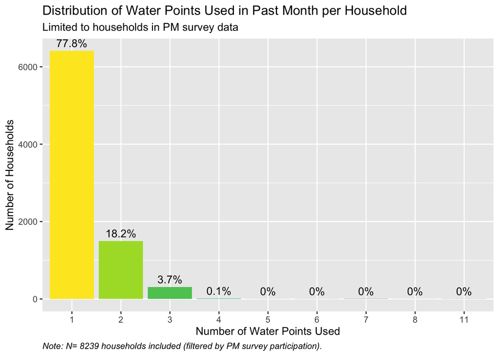

```r
# filter for HHs in promoter lists
hh_census_pm_list <- hh_census %>%
  dplyr::filter(promoter_list == TRUE)

wp_distribution_census <- hh_census_pm_list %>%
  # number of secondary water points plus one = total number of water points
  mutate(total_wp_used = if_else(is.na(wp_secweekno), 1L, wp_secweekno + 1L)) %>%
  count(total_wp_used) %>%
  mutate(
    percentage = round(n / sum(n) * 100, 1),
    label = paste0(percentage, "%")
  )

# sample (used in caption)
total_households_census <- length(unique(trimws(as.character(hh_census_pm_list$household_id))))

# plot
ggplot(wp_distribution_census, aes(x = as.factor(total_wp_used), y = n, fill = as.factor(total_wp_used))) +
  geom_col() +
  geom_text(
    aes(label = label),
    vjust = -0.5,
    color = "black"
  ) +
  scale_fill_viridis_d(option = "D", direction = -1, name = "Water Points Used") +
  labs(
    title = "Distribution of Water Points Used in Past Month per Household",
    subtitle = "Limited to households in PM survey data",
    x = "Number of Water Points Used",
    y = "Number of Households",
    caption = paste0("Note: N= ",total_households_census," households included (filtered by PM survey participation).")) +
  # theme +
  theme(
    plot.caption = element_text(hjust = 0, face = "italic"),
    legend.position = "none"
  )
```

## number of water points used per household - households NOT in promoter lists

very similar to above - 2pp higher share using just 1 water point

[figure not shown]

```r
# filter for HHs in promoter lists
hh_census_not_pm_list <- hh_census %>%
  dplyr::filter(promoter_list != TRUE)

wp_distribution_census <- hh_census_not_pm_list %>%
  # number of secondary water points plus one = total number of water points
  mutate(total_wp_used = if_else(is.na(wp_secweekno), 1L, wp_secweekno + 1L)) %>%
  count(total_wp_used) %>%
  mutate(
    percentage = round(n / sum(n) * 100, 1),
    label = paste0(percentage, "%")
  )

# sample (used in caption)
total_households_census <- length(unique(trimws(as.character(hh_census_not_pm_list$household_id))))

# plot
ggplot(wp_distribution_census, aes(x = as.factor(total_wp_used), y = n, fill = as.factor(total_wp_used))) +
  geom_col() +
  geom_text(
    aes(label = label),
    vjust = -0.5,
    color = "black"
  ) +
  scale_fill_viridis_d(option = "D", direction = -1, name = "Water Points Used") +
  labs(
    title = "Distribution of Water Points Used in Past Month per Household",
    subtitle = "Limited to households in PM survey data",
    x = "Number of Water Points Used",
    y = "Number of Households",
    caption = paste0("Note: N= ",total_households_census," households included (not in PM survey).")) +
  # theme +
  theme(
    plot.caption = element_text(hjust = 0, face = "italic"),
    legend.position = "none"
  )
```